# Project: Identify Customer Segments

In this project, you will apply unsupervised learning techniques to identify segments of the population that form the core customer base for a mail-order sales company in Germany. These segments can then be used to direct marketing campaigns towards audiences that will have the highest expected rate of returns. The data that you will use has been provided by our partners at Bertelsmann Arvato Analytics, and represents a real-life data science task.

This notebook will help you complete this task by providing a framework within which you will perform your analysis steps. In each step of the project, you will see some text describing the subtask that you will perform, followed by one or more code cells for you to complete your work. **Feel free to add additional code and markdown cells as you go along so that you can explore everything in precise chunks.** The code cells provided in the base template will outline only the major tasks, and will usually not be enough to cover all of the minor tasks that comprise it.

It should be noted that while there will be precise guidelines on how you should handle certain tasks in the project, there will also be places where an exact specification is not provided. **There will be times in the project where you will need to make and justify your own decisions on how to treat the data.** These are places where there may not be only one way to handle the data. In real-life tasks, there may be many valid ways to approach an analysis task. One of the most important things you can do is clearly document your approach so that other scientists can understand the decisions you've made.

At the end of most sections, there will be a Markdown cell labeled **Discussion**. In these cells, you will report your findings for the completed section, as well as document the decisions that you made in your approach to each subtask. **Your project will be evaluated not just on the code used to complete the tasks outlined, but also your communication about your observations and conclusions at each stage.**

```python
# import libraries here; add more as necessary
import numpy as np
import pandas as pd
import math
import matplotlib.pyplot as plt
import seaborn as sns
from sklearn.preprocessing import Imputer, StandardScaler
from sklearn.decomposition import PCA
from sklearn.cluster import KMeans
from sklearn.metrics import silhouette_score
from collections import Counter

# magic word for producing visualizations in notebook
%matplotlib inline
```

```python
# Seting random seeds
np.random.seed(0)
```

### Step 0: Load the Data

There are four files associated with this project (not including this one):

- `Udacity_AZDIAS_Subset.csv`: Demographics data for the general population of Germany; 891211 persons (rows) x 85 features (columns).
- `Udacity_CUSTOMERS_Subset.csv`: Demographics data for customers of a mail-order company; 191652 persons (rows) x 85 features (columns).
- `Data_Dictionary.md`: Detailed information file about the features in the provided datasets.
- `AZDIAS_Feature_Summary.csv`: Summary of feature attributes for demographics data; 85 features (rows) x 4 columns

Each row of the demographics files represents a single person, but also includes information outside of individuals, including information about their household, building, and neighborhood. You will use this information to cluster the general population into groups with similar demographic properties. Then, you will see how the people in the customers dataset fit into those created clusters. The hope here is that certain clusters are over-represented in the customers data, as compared to the general population; those over-represented clusters will be assumed to be part of the core userbase. This information can then be used for further applications, such as targeting for a marketing campaign.

To start off with, load in the demographics data for the general population into a pandas DataFrame, and do the same for the feature attributes summary. Note for all of the `.csv` data files in this project: they're semicolon (`;`) delimited, so you'll need an additional argument in your [`read_csv()`](https://pandas.pydata.org/pandas-docs/stable/generated/pandas.read_csv.html) call to read in the data properly. Also, considering the size of the main dataset, it may take some time for it to load completely.

Once the dataset is loaded, it's recommended that you take a little bit of time just browsing the general structure of the dataset and feature summary file. You'll be getting deep into the innards of the cleaning in the first major step of the project, so gaining some general familiarity can help you get your bearings.

```python
# Load in the general demographics data.
azdias = pd.read_csv('Udacity_AZDIAS_Subset.csv', sep=';')

# Load in the feature summary file.
feat_info = pd.read_csv('AZDIAS_Feature_Summary.csv', sep=';')
```

```python
# Check the structure of the data after it's loaded (e.g. print the number of
# rows and columns, print the first few rows).
print(azdias.head())
```

```
   AGER_TYP  ALTERSKATEGORIE_GROB  ANREDE_KZ  CJT_GESAMTTYP  \
0        -1                     2          1            2.0
1        -1                     1          2            5.0
2        -1                     3          2            3.0
3         2                     4          2            2.0
4        -1                     3          1            5.0

   FINANZ_MINIMALIST  FINANZ_SPARER  FINANZ_VORSORGER  FINANZ_ANLEGER  \
0                  3              4                 3               5
1                  1              5                 2               5
2                  1              4                 1               2
3                  4              2                 5               2
4                  4              3                 4               1

   FINANZ_UNAUFFAELLIGER  FINANZ_HAUSBAUER    ...     PLZ8_ANTG1  PLZ8_ANTG2  \
```

[output cut: 21 more lines]

```python
print(azdias.describe())
```

```
            AGER_TYP  ALTERSKATEGORIE_GROB      ANREDE_KZ  CJT_GESAMTTYP  \
count  891221.000000         891221.000000  891221.000000  886367.000000
mean       -0.358435              2.777398       1.522098       3.632838
std         1.198724              1.068775       0.499512       1.595021
min        -1.000000              1.000000       1.000000       1.000000
25%        -1.000000              2.000000       1.000000       2.000000
50%        -1.000000              3.000000       2.000000       4.000000
75%        -1.000000              4.000000       2.000000       5.000000
max         3.000000              9.000000       2.000000       6.000000

       FINANZ_MINIMALIST  FINANZ_SPARER  FINANZ_VORSORGER  FINANZ_ANLEGER  \
count      891221.000000  891221.000000     891221.000000   891221.000000
mean            3.074528       2.821039          3.401106        3.033328
std             1.321055       1.464749          1.322134        1.529603
min             1.000000       1.000000          1.000000        1.000000
25%             2.000000       1.000000          3.000000        2.000000
50%             3.000000       3.000000          3.000000        3.000000
75%             4.000000       4.000000          5.000000        5.000000
max             5.000000       5.000000          5.000000        5.000000

       FINANZ_UNAUFFAELLIGER  FINANZ_HAUSBAUER      ...          PLZ8_ANTG1  \
count          891221.000000     891221.000000      ...       774706.000000
mean                2.874167          3.075121      ...            2.253330
std                 1.486731          1.353248      ...            0.972008
min                 1.000000          1.000000      ...            0.000000
25%                 2.000000          2.000000      ...            1.000000
50%                 3.000000          3.000000      ...            2.000000
75%                 4.000000          4.000000      ...            3.000000
max                 5.000000          5.000000      ...            4.000000

          PLZ8_ANTG2     PLZ8_ANTG3     PLZ8_ANTG4    PLZ8_BAUMAX  \
count  774706.000000  774706.000000  774706.000000  774706.000000
mean        2.801858       1.595426       0.699166       1.943913
std         0.920309       0.986736       0.727137       1.459654
min         0.000000       0.000000       0.000000       1.000000
25%         2.000000       1.000000       0.000000       1.000000
50%         3.000000       2.000000       1.000000       1.000000
75%         3.000000       2.000000       1.000000       3.000000
max         4.000000       3.000000       2.000000       5.000000

            PLZ8_HHZ       PLZ8_GBZ         ARBEIT    ORTSGR_KLS9  \
count  774706.000000  774706.000000  794005.000000  794005.000000
mean        3.612821       3.381087       3.167854       5.293002
std         0.973967       1.111598       1.002376       2.303739
min         1.000000       1.000000       1.000000       0.000000
25%         3.000000       3.000000       3.000000       4.000000
50%         4.000000       3.000000       3.000000       5.000000
75%         4.000000       4.000000       4.000000       7.000000
max         5.000000       5.000000       9.000000       9.000000

           RELAT_AB
count  794005.00000
mean        3.07222
std         1.36298
min         1.00000
25%         2.00000
50%         3.00000
75%         4.00000
max         9.00000

[8 rows x 81 columns]
```

```python
print(feat_info[0:20])
```

```
                attribute information_level         type missing_or_unknown
0                AGER_TYP            person  categorical             [-1,0]
1    ALTERSKATEGORIE_GROB            person      ordinal           [-1,0,9]
2               ANREDE_KZ            person  categorical             [-1,0]
3           CJT_GESAMTTYP            person  categorical                [0]
4       FINANZ_MINIMALIST            person      ordinal               [-1]
5           FINANZ_SPARER            person      ordinal               [-1]
6        FINANZ_VORSORGER            person      ordinal               [-1]
7          FINANZ_ANLEGER            person      ordinal               [-1]
8   FINANZ_UNAUFFAELLIGER            person      ordinal               [-1]
9        FINANZ_HAUSBAUER            person      ordinal               [-1]
10              FINANZTYP            person  categorical               [-1]
11            GEBURTSJAHR            person      numeric                [0]
12        GFK_URLAUBERTYP            person  categorical                 []
13       GREEN_AVANTGARDE            person  categorical                 []
14             HEALTH_TYP            person      ordinal             [-1,0]
15    LP_LEBENSPHASE_FEIN            person        mixed                [0]
16    LP_LEBENSPHASE_GROB            person        mixed                [0]
17        LP_FAMILIE_FEIN            person  categorical                [0]
18        LP_FAMILIE_GROB            person  categorical                [0]
19         LP_STATUS_FEIN            person  categorical                [0]
```

```python
print(feat_info[20:40])
```

```
                attribute information_level         type missing_or_unknown
20         LP_STATUS_GROB            person  categorical                [0]
21       NATIONALITAET_KZ            person  categorical             [-1,0]
22  PRAEGENDE_JUGENDJAHRE            person        mixed             [-1,0]
23         RETOURTYP_BK_S            person      ordinal                [0]
24              SEMIO_SOZ            person      ordinal             [-1,9]
25              SEMIO_FAM            person      ordinal             [-1,9]
26              SEMIO_REL            person      ordinal             [-1,9]
27              SEMIO_MAT            person      ordinal             [-1,9]
28             SEMIO_VERT            person      ordinal             [-1,9]
29             SEMIO_LUST            person      ordinal             [-1,9]
30              SEMIO_ERL            person      ordinal             [-1,9]
31             SEMIO_KULT            person      ordinal             [-1,9]
32              SEMIO_RAT            person      ordinal             [-1,9]
33             SEMIO_KRIT            person      ordinal             [-1,9]
34              SEMIO_DOM            person      ordinal             [-1,9]
35             SEMIO_KAEM            person      ordinal             [-1,9]
36          SEMIO_PFLICHT            person      ordinal             [-1,9]
37            SEMIO_TRADV            person      ordinal             [-1,9]
38            SHOPPER_TYP            person  categorical               [-1]
39                SOHO_KZ            person  categorical               [-1]
```

```python
print(feat_info[40:60])
```

```
              attribute information_level         type missing_or_unknown
40             TITEL_KZ            person  categorical             [-1,0]
41             VERS_TYP            person  categorical               [-1]
42             ZABEOTYP            person  categorical             [-1,9]
43             ALTER_HH         household     interval                [0]
44         ANZ_PERSONEN         household      numeric                 []
45            ANZ_TITEL         household      numeric                 []
46   HH_EINKOMMEN_SCORE         household      ordinal             [-1,0]
47         KK_KUNDENTYP         household  categorical               [-1]
48       W_KEIT_KIND_HH         household      ordinal             [-1,0]
49       WOHNDAUER_2008         household      ordinal             [-1,0]
50  ANZ_HAUSHALTE_AKTIV          building      numeric                [0]
51         ANZ_HH_TITEL          building      numeric                 []
52          GEBAEUDETYP          building  categorical             [-1,0]
53          KONSUMNAEHE          building      ordinal                 []
54     MIN_GEBAEUDEJAHR          building      numeric                [0]
55          OST_WEST_KZ          building  categorical               [-1]
56             WOHNLAGE          building        mixed               [-1]
57      CAMEO_DEUG_2015     microcell_rr4  categorical             [-1,X]
58       CAMEO_DEU_2015     microcell_rr4  categorical               [XX]
59      CAMEO_INTL_2015     microcell_rr4        mixed            [-1,XX]
```

```python
print(feat_info[60:80])
```

```
             attribute information_level     type missing_or_unknown
60         KBA05_ANTG1     microcell_rr3  ordinal               [-1]
61         KBA05_ANTG2     microcell_rr3  ordinal               [-1]
62         KBA05_ANTG3     microcell_rr3  ordinal               [-1]
63         KBA05_ANTG4     microcell_rr3  ordinal               [-1]
64        KBA05_BAUMAX     microcell_rr3    mixed             [-1,0]
65           KBA05_GBZ     microcell_rr3  ordinal             [-1,0]
66            BALLRAUM          postcode  ordinal               [-1]
67            EWDICHTE          postcode  ordinal               [-1]
68          INNENSTADT          postcode  ordinal               [-1]
69  GEBAEUDETYP_RASTER        region_rr1  ordinal                 []
70                 KKK        region_rr1  ordinal             [-1,0]
71          MOBI_REGIO        region_rr1  ordinal                 []
72   ONLINE_AFFINITAET        region_rr1  ordinal                 []
73            REGIOTYP        region_rr1  ordinal             [-1,0]
74    KBA13_ANZAHL_PKW    macrocell_plz8  numeric                 []
75          PLZ8_ANTG1    macrocell_plz8  ordinal               [-1]
76          PLZ8_ANTG2    macrocell_plz8  ordinal               [-1]
77          PLZ8_ANTG3    macrocell_plz8  ordinal               [-1]
78          PLZ8_ANTG4    macrocell_plz8  ordinal               [-1]
79         PLZ8_BAUMAX    macrocell_plz8    mixed             [-1,0]
```

```python
print(feat_info[80:])
```

```
      attribute information_level     type missing_or_unknown
80     PLZ8_HHZ    macrocell_plz8  ordinal               [-1]
81     PLZ8_GBZ    macrocell_plz8  ordinal               [-1]
82       ARBEIT         community  ordinal             [-1,9]
83  ORTSGR_KLS9         community  ordinal             [-1,0]
84     RELAT_AB         community  ordinal             [-1,9]
```

> **Tip**: Add additional cells to keep everything in reasonably-sized chunks! Keyboard shortcut `esc --> a` (press escape to enter command mode, then press the 'A' key) adds a new cell before the active cell, and `esc --> b` adds a new cell after the active cell. If you need to convert an active cell to a markdown cell, use `esc --> m` and to convert to a code cell, use `esc --> y`.

## Step 1: Preprocessing

### Step 1.1: Assess Missing Data

The feature summary file contains a summary of properties for each demographics data column. You will use this file to help you make cleaning decisions during this stage of the project. First of all, you should assess the demographics data in terms of missing data. Pay attention to the following points as you perform your analysis, and take notes on what you observe. Make sure that you fill in the **Discussion** cell with your findings and decisions at the end of each step that has one!

#### Step 1.1.1: Convert Missing Value Codes to NaNs

The fourth column of the feature attributes summary (loaded in above as `feat_info`) documents the codes from the data dictionary that indicate missing or unknown data. While the file encodes this as a list (e.g. `[-1,0]`), this will get read in as a string object. You'll need to do a little bit of parsing to make use of it to identify and clean the data. Convert data that matches a 'missing' or 'unknown' value code into a numpy NaN value. You might want to see how much data takes on a 'missing' or 'unknown' code, and how much data is naturally missing, as a point of interest.

**As one more reminder, you are encouraged to add additional cells to break up your analysis into manageable chunks.**

```python
# Identify missing or unknown data values and convert them to NaNs.

def replace_with_NaN(azdias, feat_info):
    """ Replace all unknown data values wilth NaNs. Unknown data values are values specified in the AZDIAS_Feature_Summary
    csv file.
    INPUTS:
        azdias - azdias customer dataframe to be processed
        feat_info - dataframe for AZDIAS_Feature_Summary csv
    OUTPUTS:
        azdias - azdias customer dataframe with unknown data values replaced with NaNs
    """
    string_ints = ['-1','0','1','2','3','4','5','6','7','8','9']
    # Dictionary to store processed missing or unknow values for each column of azdias
    values_to_replace = {}
    # Looping through each column of azdias dataframe
    for col_num in range(feat_info.shape[0]):
        # Get the missing or unknown values in the current column of the azdias dataframe
        missing_unknown_values = feat_info.iloc[col_num, 3]
        # Removing "[" and "]" from missing_unknown_values strings
        for char in '[]':
            missing_unknown_values = missing_unknown_values.replace(char,'')
        if ',' in missing_unknown_values: # More than one missing or unknow values
            missing_unknown_values = missing_unknown_values.split(sep=',')
        elif len(missing_unknown_values) > 0: # One missing or unknown value
            value = missing_unknown_values
            missing_unknown_values = []
            missing_unknown_values.append(value)
        else: # No missing or unknown value
            missing_unknown_values = []
        for i in range(len(missing_unknown_values)):
            # Replace all string representations of integers into integers
            if missing_unknown_values[i] in string_ints:
                missing_unknown_values[i] = int(missing_unknown_values[i])
        if len(missing_unknown_values) > 0: # If there are values to replace with NaN, add to dictionary
            values_to_replace[feat_info.iloc[col_num, 0]] = missing_unknown_values
    #print(values_to_replace)
    azdias = azdias.replace(values_to_replace, np.nan)
    return azdias
azdias = replace_with_NaN(azdias, feat_info)
```

#### Step 1.1.2: Assess Missing Data in Each Column

How much missing data is present in each column? There are a few columns that are outliers in terms of the proportion of values that are missing. You will want to use matplotlib's [`hist()`](https://matplotlib.org/api/_as_gen/matplotlib.pyplot.hist.html) function to visualize the distribution of missing value counts to find these columns. Identify and document these columns. While some of these columns might have justifications for keeping or re-encoding the data, for this project you should just remove them from the dataframe. (Feel free to make remarks about these outlier columns in the discussion, however!)

For the remaining features, are there any patterns in which columns have, or share, missing data?

```python
# Perform an assessment of how much missing data there is in each column of the dataset.
# Goal is to remove columns with a huge proportion of NaN values

missing_values_per_column = azdias.isnull().sum(axis=0,skipna=False)
missing_values_per_column /= azdias.shape[0]
missing_values_per_column = missing_values_per_column.tolist()
#print(missing_values_per_column[0:5])
```

```python
# Series containing proportion of missing values per column in the azdias dataframe
azdias_missing_col = pd.Series(missing_values_per_column, index=azdias.columns.values)
print(azdias_missing_col)
```

```
AGER_TYP                 0.769554
ALTERSKATEGORIE_GROB     0.003233
ANREDE_KZ                0.000000
CJT_GESAMTTYP            0.005446
FINANZ_MINIMALIST        0.000000
FINANZ_SPARER            0.000000
FINANZ_VORSORGER         0.000000
FINANZ_ANLEGER           0.000000
FINANZ_UNAUFFAELLIGER    0.000000
FINANZ_HAUSBAUER         0.000000
FINANZTYP                0.000000
GEBURTSJAHR              0.440203
GFK_URLAUBERTYP          0.005446
GREEN_AVANTGARDE         0.000000
HEALTH_TYP               0.124768
LP_LEBENSPHASE_FEIN      0.109549
LP_LEBENSPHASE_GROB      0.106115
LP_FAMILIE_FEIN          0.087287
LP_FAMILIE_GROB          0.087287
LP_STATUS_FEIN           0.005446
LP_STATUS_GROB           0.005446
NATIONALITAET_KZ         0.121536
PRAEGENDE_JUGENDJAHRE    0.121366
RETOURTYP_BK_S           0.005446
SEMIO_SOZ                0.000000
SEMIO_FAM                0.000000
SEMIO_REL                0.000000
SEMIO_MAT                0.000000
SEMIO_VERT               0.000000
SEMIO_LUST               0.000000
                           ...
OST_WEST_KZ              0.104517
WOHNLAGE                 0.104517
CAMEO_DEUG_2015          0.111479
CAMEO_DEU_2015           0.111479
CAMEO_INTL_2015          0.111479
KBA05_ANTG1              0.149597
KBA05_ANTG2              0.149597
KBA05_ANTG3              0.149597
KBA05_ANTG4              0.149597
KBA05_BAUMAX             0.534687
KBA05_GBZ                0.149597
BALLRAUM                 0.105182
EWDICHTE                 0.105182
INNENSTADT               0.105182
GEBAEUDETYP_RASTER       0.104525
KKK                      0.177357
MOBI_REGIO               0.149597
ONLINE_AFFINITAET        0.005446
REGIOTYP                 0.177357
KBA13_ANZAHL_PKW         0.118714
PLZ8_ANTG1               0.130736
PLZ8_ANTG2               0.130736
PLZ8_ANTG3               0.130736
PLZ8_ANTG4               0.130736
PLZ8_BAUMAX              0.130736
PLZ8_HHZ                 0.130736
PLZ8_GBZ                 0.130736
ARBEIT                   0.109260
ORTSGR_KLS9              0.109147
RELAT_AB                 0.109260
Length: 85, dtype: float64
```

```python
# Testing AGER_TYPE column to check if above method is right
print(azdias['AGER_TYP'].value_counts(dropna=False))
print((azdias['AGER_TYP'].value_counts(dropna=False)[np.nan])/(azdias['AGER_TYP'].value_counts(dropna=False).sum()))
```

```
NaN     685843
 2.0     98472
 1.0     79802
 3.0     27104
Name: AGER_TYP, dtype: int64
0.769554352961
```

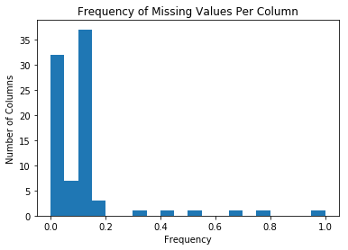

```python
# Investigate patterns in the amount of missing data in each column.
#azdias_missing_col.plot(kind='hist')
bins = np.arange(0,azdias_missing_col.max()+0.05,0.05);
plt.hist(azdias_missing_col,bins=bins);
plt.title("Frequency of Missing Values Per Column");
plt.ylabel("Number of Columns");
plt.xlabel("Frequency");
```

```python
# Remove the outlier columns from the dataset. (You'll perform other data
# engineering tasks such as re-encoding and imputation later.)

def remove_outlier_col(df, prop_miss, cutoff):
    """
    INPUTS:
        df: Main dataframe to be reduced
        prop_miss: Series containing proportion of missing values per df's column
        cutoff: Threshold for missing values per column. Between 0 to 1.
    OUTPUTS:
        reduced_df: Subset of df containing columns with fewer missing values
                    than the threshold
        col_to_remove: Columns that are removed. These columns contain a higher
                        proportion of missing values than the threshold
    """
    col_to_remove = []
    for col_num in range(df.shape[1]):
        if prop_miss[col_num] > cutoff:
            col_to_remove.append(df.columns.values[col_num])
            print("Removing column: {} with {:.4f} % missing values".format(df.columns.values[col_num],prop_miss[col_num]*100))
    return df.drop(col_to_remove,axis=1), col_to_remove

cutoff=0.3 # Set cutoff percentage for proportion of missing values for each column
azdias_cleaned, removed_columns = remove_outlier_col(azdias, azdias_missing_col, cutoff)
print(azdias_cleaned.head())
```

```
Removing column: AGER_TYP with 76.9554 % missing values
Removing column: GEBURTSJAHR with 44.0203 % missing values
Removing column: TITEL_KZ with 99.7576 % missing values
Removing column: ALTER_HH with 34.8137 % missing values
Removing column: KK_KUNDENTYP with 65.5967 % missing values
Removing column: KBA05_BAUMAX with 53.4687 % missing values
   ALTERSKATEGORIE_GROB  ANREDE_KZ  CJT_GESAMTTYP  FINANZ_MINIMALIST  \
0                   2.0          1            2.0                  3
1                   1.0          2            5.0                  1
2                   3.0          2            3.0                  1
3                   4.0          2            2.0                  4
4                   3.0          1            5.0                  4

   FINANZ_SPARER  FINANZ_VORSORGER  FINANZ_ANLEGER  FINANZ_UNAUFFAELLIGER  \
0              4                 3               5                      5
1              5                 2               5                      4
2              4                 1               2                      3
3              2                 5               2                      1
4              3                 4               1                      3

   FINANZ_HAUSBAUER  FINANZTYP    ...     PLZ8_ANTG1  PLZ8_ANTG2  PLZ8_ANTG3  \
0                 3          4    ...            NaN         NaN         NaN
1                 5          1    ...            2.0         3.0         2.0
2                 5          1    ...            3.0         3.0         1.0
3                 2          6    ...            2.0         2.0         2.0
4                 2          5    ...            2.0         4.0         2.0

   PLZ8_ANTG4  PLZ8_BAUMAX  PLZ8_HHZ  PLZ8_GBZ  ARBEIT  ORTSGR_KLS9  RELAT_AB
0         NaN          NaN       NaN       NaN     NaN          NaN       NaN
1         1.0          1.0       5.0       4.0     3.0          5.0       4.0
2         0.0          1.0       4.0       4.0     3.0          5.0       2.0
3         0.0          1.0       3.0       4.0     2.0          3.0       3.0
4         1.0          2.0       3.0       3.0     4.0          6.0       5.0

[5 rows x 79 columns]
```

#### Discussion 1.1.2: Assess Missing Data in Each Column

For the majority of the columns, missing values constituted less than 20% of their values. There were only 6 columns with a proportion of missing values that exceeded 20%. The column TITEL_KZ, which measured academic titles such as Dr and PhD, had the highest proportion of missing values with 99.76%. AGER_TYP, which measured the type of elderly (passive, cultural, experience-driven), had the second highest proportion of missing values at 76.96%. Since the vast majority of the population were unlikely to hold academic titles such as Dr, PhD and were neither elderly, it made sense for these two variables to have high proportion of missing values. Hence, we could safely drop these two variables. KK_KUNDENTYP ranked third in the proportion of missing values at 65.60%. This variable measured the consumer pattern (regular, active, passive, etc) over the past 12 months. KBA05_BAUMAX, which measured the most common building type within the microcell, had the fourth highest rate at 53.47%, followed by GEBURTSJAHR (44.02%) which measured year of birth and ALTER_HH (34.81%) which measured the birthdate of the head of household. Considering that all other columns had a proportion of missing values ranging from 0 to 20%, the decision was made to drop all 6 of the aforementioned columns. In addition, these 6 columns might not be as useful for clustering purposes if a huge majority of them had to be imputed with similar common values.

#### Step 1.1.3: Assess Missing Data in Each Row

Now, you'll perform a similar assessment for the rows of the dataset. How much data is missing in each row? As with the columns, you should see some groups of points that have a very different numbers of missing values. Divide the data into two subsets: one for data points that are above some threshold for missing values, and a second subset for points below that threshold.

In order to know what to do with the outlier rows, we should see if the distribution of data values on columns that are not missing data (or are missing very little data) are similar or different between the two groups. Select at least five of these columns and compare the distribution of values.

- You can use seaborn's [`countplot()`](https://seaborn.pydata.org/generated/seaborn.countplot.html) function to create a bar chart of code frequencies and matplotlib's [`subplot()`](https://matplotlib.org/api/_as_gen/matplotlib.pyplot.subplot.html) function to put bar charts for the two subplots side by side.
- To reduce repeated code, you might want to write a function that can perform this comparison, taking as one of its arguments a column to be compared.

Depending on what you observe in your comparison, this will have implications on how you approach your conclusions later in the analysis. If the distributions of non-missing features look similar between the data with many missing values and the data with few or no missing values, then we could argue that simply dropping those points from the analysis won't present a major issue. On the other hand, if the data with many missing values looks very different from the data with few or no missing values, then we should make a note on those data as special. Make sure you report your observations in the discussion section. **Either way, you should continue your analysis below using just the subset of the data with few or no missing values.**

```python
# How much data is missing in each row of the dataset?
missing_values_per_row = azdias_cleaned.isnull().sum(axis=1,skipna=False)
missing_values_per_row /= azdias_cleaned.shape[1]
missing_values_per_row = missing_values_per_row.tolist()
azdias_missing_row = pd.Series(missing_values_per_row)
print(azdias_missing_row)
```

```
0         0.544304
1         0.000000
2         0.000000
3         0.088608
4         0.000000
5         0.000000
6         0.000000
7         0.000000
8         0.000000
9         0.000000
10        0.000000
11        0.594937
12        0.075949
13        0.101266
14        0.594937
```

[output cut: 47 more lines]

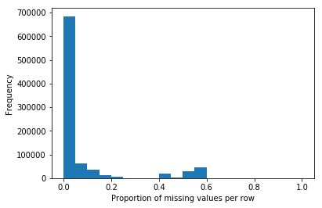

```python
# Plotting histogram of missing values per column
bins = np.arange(0,1.05,0.05);
plt.hist(azdias_missing_row,bins=bins);
plt.xlabel("Proportion of missing values per row");
plt.ylabel("Frequency");
```

```python
# Write code to divide the data into two subsets based on the number of missing
# values in each row.

# Appending column containg info on proportion of missing values per row to the azdias dataframe from step 1.1.2
azdias_cleaned_nan = pd.concat([azdias_cleaned, azdias_missing_row.rename('NaN_val')], axis=1, join_axes=[azdias_cleaned.index])
# Set threshold for missing values
threshold = 0.3
# Subset containg rows of Azdias dataframe from step 1.1.2 that are below the threshold for missing values
azdias_cleaned_below_thres = azdias_cleaned_nan[azdias_cleaned_nan['NaN_val'] < threshold]
# Subset containg rows of Azdias dataframe from step 1.1.2 that are above the threshold for missing values
azdias_cleaned_above_thres = azdias_cleaned_nan[azdias_cleaned_nan['NaN_val'] >= threshold]

#print(azdias_cleaned_below_thres.head())
#print(azdias_cleaned_above_thres.head())
```

```python
# Retrieving proportion of missing values per column for azdias dataframe in 1.1.2
missing_values_per_column = azdias_cleaned.isnull().sum(axis=0,skipna=False)
missing_values_per_column /= azdias_cleaned.shape[0]
missing_values_per_column = missing_values_per_column.tolist()
azdias_cleaned_col_miss = pd.Series(missing_values_per_column, index=azdias_cleaned.columns.values)
print(azdias_cleaned_col_miss)
```

```
ALTERSKATEGORIE_GROB     0.003233
ANREDE_KZ                0.000000
CJT_GESAMTTYP            0.005446
FINANZ_MINIMALIST        0.000000
FINANZ_SPARER            0.000000
FINANZ_VORSORGER         0.000000
FINANZ_ANLEGER           0.000000
FINANZ_UNAUFFAELLIGER    0.000000
FINANZ_HAUSBAUER         0.000000
FINANZTYP                0.000000
GFK_URLAUBERTYP          0.005446
GREEN_AVANTGARDE         0.000000
HEALTH_TYP               0.124768
LP_LEBENSPHASE_FEIN      0.109549
LP_LEBENSPHASE_GROB      0.106115
LP_FAMILIE_FEIN          0.087287
LP_FAMILIE_GROB          0.087287
LP_STATUS_FEIN           0.005446
LP_STATUS_GROB           0.005446
NATIONALITAET_KZ         0.121536
PRAEGENDE_JUGENDJAHRE    0.121366
RETOURTYP_BK_S           0.005446
SEMIO_SOZ                0.000000
SEMIO_FAM                0.000000
SEMIO_REL                0.000000
SEMIO_MAT                0.000000
SEMIO_VERT               0.000000
SEMIO_LUST               0.000000
SEMIO_ERL                0.000000
SEMIO_KULT               0.000000
                           ...
MIN_GEBAEUDEJAHR         0.104517
OST_WEST_KZ              0.104517
WOHNLAGE                 0.104517
CAMEO_DEUG_2015          0.111479
CAMEO_DEU_2015           0.111479
CAMEO_INTL_2015          0.111479
KBA05_ANTG1              0.149597
KBA05_ANTG2              0.149597
KBA05_ANTG3              0.149597
KBA05_ANTG4              0.149597
KBA05_GBZ                0.149597
BALLRAUM                 0.105182
EWDICHTE                 0.105182
INNENSTADT               0.105182
GEBAEUDETYP_RASTER       0.104525
KKK                      0.177357
MOBI_REGIO               0.149597
ONLINE_AFFINITAET        0.005446
REGIOTYP                 0.177357
KBA13_ANZAHL_PKW         0.118714
PLZ8_ANTG1               0.130736
PLZ8_ANTG2               0.130736
PLZ8_ANTG3               0.130736
PLZ8_ANTG4               0.130736
PLZ8_BAUMAX              0.130736
PLZ8_HHZ                 0.130736
PLZ8_GBZ                 0.130736
ARBEIT                   0.109260
ORTSGR_KLS9              0.109147
RELAT_AB                 0.109260
Length: 79, dtype: float64
```

```python
# Find columns with no missing values

def col_wo_missing(df1, df2):
    """
    INPUTS
        df1: The main dataframe containing all columns
        df2: The series that contain the proportion of missing values in each df1 column
    OUTPUTS
        columns_wo_missing: The columns in df1 that do not contain any missing values
    """
    columns_wo_missing = []
    for col_num in range(len(df2)):
        if df2[col_num] == 0:
            columns_wo_missing.append(df1.columns.values[col_num])
    return columns_wo_missing

# Retrieving columns without missing values
col_wo_missing_val = col_wo_missing(azdias_cleaned, azdias_cleaned_col_miss)
print("Columns without missing values")
print(col_wo_missing_val)
```

```
Columns without missing values
['ANREDE_KZ', 'FINANZ_MINIMALIST', 'FINANZ_SPARER', 'FINANZ_VORSORGER', 'FINANZ_ANLEGER', 'FINANZ_UNAUFFAELLIGER', 'FINANZ_HAUSBAUER', 'FINANZTYP', 'GREEN_AVANTGARDE', 'SEMIO_SOZ', 'SEMIO_FAM', 'SEMIO_REL', 'SEMIO_MAT', 'SEMIO_VERT', 'SEMIO_LUST', 'SEMIO_ERL', 'SEMIO_KULT', 'SEMIO_RAT', 'SEMIO_KRIT'…
```

```python
# Subset containg rows of Azdias dataframe from step 1.1.2 that are below the threshold
# for missing values and do not contain columns with missing values
azdias_below_thres_wo_missing_val = azdias_cleaned_below_thres[col_wo_missing_val]
# Subset containg rows of Azdias dataframe from step 1.1.2 that are above the threshold
# for missing values and do not contain columns with missing values
azdias_above_thres_wo_missing_val = azdias_cleaned_above_thres[col_wo_missing_val]

#print(azdias_below_thres_wo_missing_val.head())
#print(azdias_above_thres_wo_missing_val.head())
```

```python
def plot_histogram(df1, df2, features):
    """ Plot two histrograms side by side comparing frequency of values from both df1 and df2.
    INPUTS:
        df1: Dataframe containing rows of data below the threshold of missing values per row
        df2: Dataframe containing rows of data above the threshold of missing values per row
        feature: The features to be plotted
    """
    num_rows = math.ceil(len(features)/2)
    f, ax = plt.subplots(num_rows, 2, figsize = (50,200))
    feat_num = 0
    for row_i in range(num_rows):
        left_feat = features[feat_num]
        feat_num += 1
        right_feat = features[feat_num]
        feat_num += 1
        label = ["Dataset below threshold", "Dataset above threshold"]

        ax[row_i,0].hist([df1[left_feat], df2[left_feat]],color=['r','b'],histtype='bar',label=label)
        ax[row_i,0].set_xlabel("Feature: {}".format(left_feat), fontsize=40)
        ax[row_i,0].set_ylabel("Frequency", fontsize=40)
        ax[row_i,0].xaxis.set_tick_params(labelsize=30)
        ax[row_i,0].yaxis.set_tick_params(labelsize=30)
        ax[row_i,0].legend(loc=0, fontsize=25)

        ax[row_i,1].hist([df1[right_feat], df2[right_feat]],color=['r','b'],histtype='bar',label=label)
        ax[row_i,1].set_xlabel("Feature: {}".format(right_feat), fontsize=40)
        ax[row_i,1].set_ylabel("Frequency", fontsize=40)
        ax[row_i,1].xaxis.set_tick_params(labelsize=30)
        ax[row_i,1].yaxis.set_tick_params(labelsize=30)
        ax[row_i,1].legend(loc=0, fontsize=25)
```

```python
plot_histogram(azdias_below_thres_wo_missing_val, azdias_above_thres_wo_missing_val, col_wo_missing_val)
```

[figure not shown]

```python
# Final dataset comprised of rows containing fewer missing values per row than the selected threshold
# Drop NaN_val column after all is done
azdias_cleaned = azdias_cleaned_below_thres.drop('NaN_val',axis=1)
print(azdias_cleaned.head())
```

```
   ALTERSKATEGORIE_GROB  ANREDE_KZ  CJT_GESAMTTYP  FINANZ_MINIMALIST  \
1                   1.0          2            5.0                  1
2                   3.0          2            3.0                  1
3                   4.0          2            2.0                  4
4                   3.0          1            5.0                  4
5                   1.0          2            2.0                  3

   FINANZ_SPARER  FINANZ_VORSORGER  FINANZ_ANLEGER  FINANZ_UNAUFFAELLIGER  \
1              5                 2               5                      4
2              4                 1               2                      3
3              2                 5               2                      1
4              3                 4               1                      3
5              1                 5               2                      2

   FINANZ_HAUSBAUER  FINANZTYP    ...     PLZ8_ANTG1  PLZ8_ANTG2  PLZ8_ANTG3  \
1                 5          1    ...            2.0         3.0         2.0
2                 5          1    ...            3.0         3.0         1.0
3                 2          6    ...            2.0         2.0         2.0
4                 2          5    ...            2.0         4.0         2.0
5                 5          2    ...            2.0         3.0         1.0

   PLZ8_ANTG4  PLZ8_BAUMAX  PLZ8_HHZ  PLZ8_GBZ  ARBEIT  ORTSGR_KLS9  RELAT_AB
1         1.0          1.0       5.0       4.0     3.0          5.0       4.0
2         0.0          1.0       4.0       4.0     3.0          5.0       2.0
3         0.0          1.0       3.0       4.0     2.0          3.0       3.0
4         1.0          2.0       3.0       3.0     4.0          6.0       5.0
5         1.0          1.0       5.0       5.0     2.0          3.0       3.0

[5 rows x 79 columns]
```

#### Discussion 1.1.3: Assess Missing Data in Each Row

Two distinct groups of rows can be identified from the histogram depicting the number of rows vs the proportion of missing values per row. Most of the rows in the dataset constitute the first group, and these rows have a proportion of missing value that is less than 20%. The second group is comprised of the outlier rows, which often have a proportion of missing values that is between 40% and 60%. Hence, the threshold is set at 30% to seperate the two groups.

The reason why these outlier rows have such a concentrated distribution needs more investigation. It is abnormal that the values of so many rows fall under the same value. Perhaps these rows were obtained from a single data source that filled in similar values during data collection. In this event, these outlier rows might be an inaccurate depiction of the population, and should be dropped from the analysis.

## Step 1.2: Select and Re-Encode Features

Checking for missing data isn't the only way in which you can prepare a dataset for analysis. Since the unsupervised learning techniques to be used will only work on data that is encoded numerically, you need to make a few encoding changes or additional assumptions to be able to make progress. In addition, while almost all of the values in the dataset are encoded using numbers, not all of them represent numeric values. Check the third column of the feature summary (`feat_info`) for a summary of types of measurement.

- For numeric and interval data, these features can be kept without changes.
- Most of the variables in the dataset are ordinal in nature. While ordinal values may technically be non-linear in spacing, make the simplifying assumption that the ordinal variables can be treated as being interval in nature (that is, kept without any changes).
- Special handling may be necessary for the remaining two variable types: categorical, and 'mixed'.

In the first two parts of this sub-step, you will perform an investigation of the categorical and mixed-type features and make a decision on each of them, whether you will keep, drop, or re-encode each. Then, in the last part, you will create a new data frame with only the selected and engineered columns.

Data wrangling is often the trickiest part of the data analysis process, and there's a lot of it to be done here. But stick with it: once you're done with this step, you'll be ready to get to the machine learning parts of the project!

```python
# How many features are there of each data type?

# Finding all available features in cleaned and reduced dataset
cleaned_features = azdias_cleaned.columns.values
#print(cleaned_features)
feat_info_cleaned = feat_info[feat_info['attribute'].isin(cleaned_features)]
#print(feat_info_cleaned.head())

type_counts = feat_info_cleaned['type'].value_counts()
#print(type_counts)
print("Number of oridnal variables: "+str(type_counts['ordinal']))
print("Number of categorical variables: "+str(type_counts['categorical']))
print("Number of numeric variables: "+str(type_counts['numeric']))
print("Number of mixed variables: "+str(type_counts['mixed']))
```

```
Number of oridnal variables: 49
Number of categorical variables: 18
Number of numeric variables: 6
Number of mixed variables: 6
```

#### Step 1.2.1: Re-Encode Categorical Features

For categorical data, you would ordinarily need to encode the levels as dummy variables. Depending on the number of categories, perform one of the following:

- For binary (two-level) categoricals that take numeric values, you can keep them without needing to do anything.
- There is one binary variable that takes on non-numeric values. For this one, you need to re-encode the values as numbers or create a dummy variable.
- For multi-level categoricals (three or more values), you can choose to encode the values using multiple dummy variables (e.g. via [OneHotEncoder](http://scikit-learn.org/stable/modules/generated/sklearn.preprocessing.OneHotEncoder.html)), or (to keep things straightforward) just drop them from the analysis. As always, document your choices in the Discussion section.

```python
# Assess categorical variables: which are binary, which are multi-level, and
# which one needs to be re-encoded?

# Finding all categorical variables
categorical_variables = feat_info_cleaned[feat_info_cleaned['type'] == 'categorical']['attribute']
print(categorical_variables.head())
```

```
2            ANREDE_KZ
3        CJT_GESAMTTYP
10           FINANZTYP
12     GFK_URLAUBERTYP
13    GREEN_AVANTGARDE
Name: attribute, dtype: object
```

```python
def classify_categorical(df, cat_var):
    """ Identify multi-level categorical variables, binary variables that are not 0 and 1,
    and non-numeric binary variables.
    """
    multi_cat = []
    bin_cat_not_0_and_1 = []
    bin_cat_non_num = []
    for cat_feature in cat_var:
        if len(df[cat_feature].value_counts()) > 2:
            multi_cat.append(cat_feature)
        elif len(df[cat_feature].value_counts()) == 2:
            if isinstance(df[cat_feature].value_counts().index.sort_values()[0],str):
                bin_cat_non_num.append(cat_feature)
            # Check if values equal 0 and 1
            elif (df[cat_feature].value_counts().index.sort_values()[0] != 0):
                bin_cat_not_0_and_1.append(cat_feature)
    return multi_cat, bin_cat_not_0_and_1, bin_cat_non_num

multi_cat, bin_cat_not_0_and_1, bin_cat_non_num = classify_categorical(azdias_cleaned, categorical_variables)
print("Multi-level categorical variables: ")
print(multi_cat)
print("\n")
print("Binary variables that are not 0 and 1")
print(bin_cat_not_0_and_1)
print("\n")
print("Non-numeric binary variables")
print(bin_cat_non_num)
```

```
Multi-level categorical variables:
['CJT_GESAMTTYP', 'FINANZTYP', 'GFK_URLAUBERTYP', 'LP_FAMILIE_FEIN', 'LP_FAMILIE_GROB', 'LP_STATUS_FEIN', 'LP_STATUS_GROB', 'NATIONALITAET_KZ', 'SHOPPER_TYP', 'ZABEOTYP', 'GEBAEUDETYP', 'CAMEO_DEUG_2015', 'CAMEO_DEU_2015']


Binary variables that are not 0 and 1
['ANREDE_KZ', 'VERS_TYP']


Non-numeric binary variables
['OST_WEST_KZ']
```

```python
# Explore 'OST_WEST_KZ'
azdias_cleaned['OST_WEST_KZ'].value_counts(dropna=False)
```

```
W    629332
O    168505
Name: OST_WEST_KZ, dtype: int64
```

```python
# Re-encode categorical variable(s) to be kept in the analysis.

all_var_to_be_encoded = multi_cat+bin_cat_not_0_and_1+bin_cat_non_num
azdias_cleaned_dummies = pd.get_dummies(data=azdias_cleaned, columns=all_var_to_be_encoded, prefix=all_var_to_be_encoded)
print(azdias_cleaned_dummies.columns.values)
```

```
['ALTERSKATEGORIE_GROB' 'FINANZ_MINIMALIST' 'FINANZ_SPARER'
 'FINANZ_VORSORGER' 'FINANZ_ANLEGER' 'FINANZ_UNAUFFAELLIGER'
 'FINANZ_HAUSBAUER' 'GREEN_AVANTGARDE' 'HEALTH_TYP' 'LP_LEBENSPHASE_FEIN'
 'LP_LEBENSPHASE_GROB' 'PRAEGENDE_JUGENDJAHRE' 'RETOURTYP_BK_S' 'SEMIO_SOZ'
 'SEMIO_FAM' 'SEMIO_REL' 'SEMIO_MAT' 'SEMIO_VERT' 'SEMIO_LUST' 'SEMIO_ERL'
 'SEMIO_KULT' 'SEMIO_RAT' 'SEMIO_KRIT' 'SEMIO_DOM' 'SEMIO_KAEM'
 'SEMIO_PFLICHT' 'SEMIO_TRADV' 'SOHO_KZ' 'ANZ_PERSONEN' 'ANZ_TITEL'
 'HH_EINKOMMEN_SCORE' 'W_KEIT_KIND_HH' 'WOHNDAUER_2008'
 'ANZ_HAUSHALTE_AKTIV' 'ANZ_HH_TITEL' 'KONSUMNAEHE' 'MIN_GEBAEUDEJAHR'
 'WOHNLAGE' 'CAMEO_INTL_2015' 'KBA05_ANTG1' 'KBA05_ANTG2' 'KBA05_ANTG3'
 'KBA05_ANTG4' 'KBA05_GBZ' 'BALLRAUM' 'EWDICHTE' 'INNENSTADT'
 'GEBAEUDETYP_RASTER' 'KKK' 'MOBI_REGIO' 'ONLINE_AFFINITAET' 'REGIOTYP'
 'KBA13_ANZAHL_PKW' 'PLZ8_ANTG1' 'PLZ8_ANTG2' 'PLZ8_ANTG3' 'PLZ8_ANTG4'
 'PLZ8_BAUMAX' 'PLZ8_HHZ' 'PLZ8_GBZ' 'ARBEIT' 'ORTSGR_KLS9' 'RELAT_AB'
 'CJT_GESAMTTYP_1.0' 'CJT_GESAMTTYP_2.0' 'CJT_GESAMTTYP_3.0'
 'CJT_GESAMTTYP_4.0' 'CJT_GESAMTTYP_5.0' 'CJT_GESAMTTYP_6.0' 'FINANZTYP_1'
 'FINANZTYP_2' 'FINANZTYP_3' 'FINANZTYP_4' 'FINANZTYP_5' 'FINANZTYP_6'
 'GFK_URLAUBERTYP_1.0' 'GFK_URLAUBERTYP_2.0' 'GFK_URLAUBERTYP_3.0'
 'GFK_URLAUBERTYP_4.0' 'GFK_URLAUBERTYP_5.0' 'GFK_URLAUBERTYP_6.0'
 'GFK_URLAUBERTYP_7.0' 'GFK_URLAUBERTYP_8.0' 'GFK_URLAUBERTYP_9.0'
 'GFK_URLAUBERTYP_10.0' 'GFK_URLAUBERTYP_11.0' 'GFK_URLAUBERTYP_12.0'
 'LP_FAMILIE_FEIN_1.0' 'LP_FAMILIE_FEIN_2.0' 'LP_FAMILIE_FEIN_3.0'
 'LP_FAMILIE_FEIN_4.0' 'LP_FAMILIE_FEIN_5.0' 'LP_FAMILIE_FEIN_6.0'
 'LP_FAMILIE_FEIN_7.0' 'LP_FAMILIE_FEIN_8.0' 'LP_FAMILIE_FEIN_9.0'
 'LP_FAMILIE_FEIN_10.0' 'LP_FAMILIE_FEIN_11.0' 'LP_FAMILIE_GROB_1.0'
 'LP_FAMILIE_GROB_2.0' 'LP_FAMILIE_GROB_3.0' 'LP_FAMILIE_GROB_4.0'
 'LP_FAMILIE_GROB_5.0' 'LP_STATUS_FEIN_1.0' 'LP_STATUS_FEIN_2.0'
 'LP_STATUS_FEIN_3.0' 'LP_STATUS_FEIN_4.0' 'LP_STATUS_FEIN_5.0'
 'LP_STATUS_FEIN_6.0' 'LP_STATUS_FEIN_7.0' 'LP_STATUS_FEIN_8.0'
 'LP_STATUS_FEIN_9.0' 'LP_STATUS_FEIN_10.0' 'LP_STATUS_GROB_1.0'
 'LP_STATUS_GROB_2.0' 'LP_STATUS_GROB_3.0' 'LP_STATUS_GROB_4.0'
 'LP_STATUS_GROB_5.0' 'NATIONALITAET_KZ_1.0' 'NATIONALITAET_KZ_2.0'
 'NATIONALITAET_KZ_3.0' 'SHOPPER_TYP_0.0' 'SHOPPER_TYP_1.0'
 'SHOPPER_TYP_2.0' 'SHOPPER_TYP_3.0' 'ZABEOTYP_1' 'ZABEOTYP_2' 'ZABEOTYP_3'
 'ZABEOTYP_4' 'ZABEOTYP_5' 'ZABEOTYP_6' 'GEBAEUDETYP_1.0' 'GEBAEUDETYP_2.0'
 'GEBAEUDETYP_3.0' 'GEBAEUDETYP_4.0' 'GEBAEUDETYP_5.0' 'GEBAEUDETYP_6.0'
 'GEBAEUDETYP_8.0' 'CAMEO_DEUG_2015_1' 'CAMEO_DEUG_2015_2'
 'CAMEO_DEUG_2015_3' 'CAMEO_DEUG_2015_4' 'CAMEO_DEUG_2015_5'
 'CAMEO_DEUG_2015_6' 'CAMEO_DEUG_2015_7' 'CAMEO_DEUG_2015_8'
 'CAMEO_DEUG_2015_9' 'CAMEO_DEU_2015_1A' 'CAMEO_DEU_2015_1B'
 'CAMEO_DEU_2015_1C' 'CAMEO_DEU_2015_1D' 'CAMEO_DEU_2015_1E'
 'CAMEO_DEU_2015_2A' 'CAMEO_DEU_2015_2B' 'CAMEO_DEU_2015_2C'
 'CAMEO_DEU_2015_2D' 'CAMEO_DEU_2015_3A' 'CAMEO_DEU_2015_3B'
 'CAMEO_DEU_2015_3C' 'CAMEO_DEU_2015_3D' 'CAMEO_DEU_2015_4A'
 'CAMEO_DEU_2015_4B' 'CAMEO_DEU_2015_4C' 'CAMEO_DEU_2015_4D'
 'CAMEO_DEU_2015_4E' 'CAMEO_DEU_2015_5A' 'CAMEO_DEU_2015_5B'
 'CAMEO_DEU_2015_5C' 'CAMEO_DEU_2015_5D' 'CAMEO_DEU_2015_5E'
 'CAMEO_DEU_2015_5F' 'CAMEO_DEU_2015_6A' 'CAMEO_DEU_2015_6B'
 'CAMEO_DEU_2015_6C' 'CAMEO_DEU_2015_6D' 'CAMEO_DEU_2015_6E'
 'CAMEO_DEU_2015_6F' 'CAMEO_DEU_2015_7A' 'CAMEO_DEU_2015_7B'
 'CAMEO_DEU_2015_7C' 'CAMEO_DEU_2015_7D' 'CAMEO_DEU_2015_7E'
 'CAMEO_DEU_2015_8A' 'CAMEO_DEU_2015_8B' 'CAMEO_DEU_2015_8C'
 'CAMEO_DEU_2015_8D' 'CAMEO_DEU_2015_9A' 'CAMEO_DEU_2015_9B'
 'CAMEO_DEU_2015_9C' 'CAMEO_DEU_2015_9D' 'CAMEO_DEU_2015_9E' 'ANREDE_KZ_1'
 'ANREDE_KZ_2' 'VERS_TYP_1.0' 'VERS_TYP_2.0' 'OST_WEST_KZ_O'
 'OST_WEST_KZ_W']
```

#### Discussion 1.2.1: Re-Encode Categorical Features

Multi-level categorical variables were identified and modified using multiple dummy variables. These variables were CJT_GESAMTTYP, FINANZTYP, GFK_URLAUBERTYP, LP_FAMILIE_FEIN, LP_FAMILIE_GROB, LP_STATUS_FEIN, LP_STATUS_GROB, NATIONALITAET_KZ, SHOPPER_TYP, ZABEOTYP, GEBAEUDETYP, CAMEO_DEUG_2015 and CAMEO_DEU_2015.

Next, numeric binary categorical variables that had values that were not 0 and 1 were also encoded using multiple dummy variables. Two such variables were found: ANREDE_KZ and VERS_TYP.

A single non-numeric binary categorical variable, OST_WEST_KZ, was found encoded using dummy variable. Alternatively, it could have been re-engineered into numeric binary catgeorical variables (0 and 1) as well. However, the decision was made to encode it using dummy variables for simplicity sake.

Binary categorical variables with values 0 and 1, such as GREEN_AVANTGARDE, were left unmodified.

#### Step 1.2.2: Engineer Mixed-Type Features

There are a handful of features that are marked as "mixed" in the feature summary that require special treatment in order to be included in the analysis. There are two in particular that deserve attention; the handling of the rest are up to your own choices:

- "PRAEGENDE_JUGENDJAHRE" combines information on three dimensions: generation by decade, movement (mainstream vs. avantgarde), and nation (east vs. west). While there aren't enough levels to disentangle east from west, you should create two new variables to capture the other two dimensions: an interval-type variable for decade, and a binary variable for movement.
- "CAMEO_INTL_2015" combines information on two axes: wealth and life stage. Break up the two-digit codes by their 'tens'-place and 'ones'-place digits into two new ordinal variables (which, for the purposes of this project, is equivalent to just treating them as their raw numeric values).
- If you decide to keep or engineer new features around the other mixed-type features, make sure you note your steps in the Discussion section.

Be sure to check `Data_Dictionary.md` for the details needed to finish these tasks.

```python
# Find all mixture variables
mixed_variables = feat_info_cleaned[feat_info_cleaned['type'] == 'mixed']['attribute']
print(mixed_variables)
```

```
15      LP_LEBENSPHASE_FEIN
16      LP_LEBENSPHASE_GROB
22    PRAEGENDE_JUGENDJAHRE
56                 WOHNLAGE
59          CAMEO_INTL_2015
79              PLZ8_BAUMAX
Name: attribute, dtype: object
```

```python
azdias_cleaned_dummies['PRAEGENDE_JUGENDJAHRE'].value_counts(dropna=False)
#azdias_cleaned_dummies_eng.isnull().sum()
```

```
 14.0    182951
 8.0     141590
 10.0     85790
 5.0      84679
 3.0      53838
 15.0     42533
 11.0     35744
 9.0      33568
NaN       28673
 6.0      25652
 12.0     24445
 1.0      20674
 4.0      20450
 2.0       7479
 13.0      5762
 7.0       4009
Name: PRAEGENDE_JUGENDJAHRE, dtype: int64
```

```python
# Investigate "PRAEGENDE_JUGENDJAHRE" and engineer two new variables.

def process_praegende_jugendjahre(df):
    """
    NEW FEATURES:
        PRAEGENDE_JUGENDJAHRE_MOVEMENT: 0 for AVANTGARDE, 1 for MAINSTREAM
        PRAEGENDE_JUGENDJAHRE_DECADE: 0 for 1940s, 1 for 1950s, 2 for 1960s, 3 for 1970s, 4 for 1980s, 5 for 1990s
    """
    mainstream = [1,3,5,8,10,12,14]
    avantgarde = [2,4,6,7,9,11,13,15]
    decade = {1:0,2:0,3:1,4:1,5:2,6:2,7:2,8:3,9:3,10:4,11:4,12:4,13:4,14:5,15:5}
    PRAEGENDE_JUGENDJAHRE_MOVEMENT = []
    PRAEGENDE_JUGENDJAHRE_DECADE = []
    for value in df["PRAEGENDE_JUGENDJAHRE"]:
        if value in mainstream: # Movement is mainstream
            PRAEGENDE_JUGENDJAHRE_MOVEMENT.append(1) # 1 for mainstream
        elif value in avantgarde: # Movement is avantgarde
            PRAEGENDE_JUGENDJAHRE_MOVEMENT.append(0) # 0 for avantgarde
        else: # value is NaN
            PRAEGENDE_JUGENDJAHRE_MOVEMENT.append(np.nan)
        if value in decade.keys():
            PRAEGENDE_JUGENDJAHRE_DECADE.append(decade[value])
        else:
            PRAEGENDE_JUGENDJAHRE_DECADE.append(np.nan)
    df["PRAEGENDE_JUGENDJAHRE_MOVEMENT"] = PRAEGENDE_JUGENDJAHRE_MOVEMENT
    df["PRAEGENDE_JUGENDJAHRE_DECADE"] = PRAEGENDE_JUGENDJAHRE_DECADE
    df.drop("PRAEGENDE_JUGENDJAHRE", axis=1,inplace=True)
    return df

azdias_cleaned_dummies_eng = process_praegende_jugendjahre(azdias_cleaned_dummies)
print(azdias_cleaned_dummies_eng["PRAEGENDE_JUGENDJAHRE_MOVEMENT"].value_counts(dropna=False))
print(azdias_cleaned_dummies_eng["PRAEGENDE_JUGENDJAHRE_DECADE"].value_counts(dropna=False))
#print(azdias_cleaned_dummies_eng.columns.values)
```

```
 1.0    593967
 0.0    175197
NaN      28673
Name: PRAEGENDE_JUGENDJAHRE_MOVEMENT, dtype: int64
 5.0    225484
 3.0    175158
 4.0    151741
 2.0    114340
 1.0     74288
NaN      28673
 0.0     28153
Name: PRAEGENDE_JUGENDJAHRE_DECADE, dtype: int64
```

```python
azdias_cleaned_dummies['CAMEO_INTL_2015'].value_counts(dropna=False)
```

```
51     133691
41      92336
24      91145
14      62877
43      56669
54      45388
25      39619
22      33146
23      26728
13      26330
45      26132
55      23953
52      20542
31      19009
34      18522
15      16974
44      14820
12      13244
35      10355
32      10354
33       9934
NaN      6069
Name: CAMEO_INTL_2015, dtype: int64
```

```python
# Investigate "CAMEO_INTL_2015" and engineer two new variables.

def process_cameo_intl_2015(df):
    """
    NEW FEATURES:
        CAMEO_INTL_2015_WEALTH: 1 for WEALTHY, 2 for PROSPEROUS, 3 for COMFORTABLE, 4 for LESS AFFLUENT, 5 for POORER
        CAMEO_INTL_2015_LIFE_STAGE: 1 for Pre-Family Couples & Singles, 2 for Young Couples With Children,
                                    3 for Families With School Age Children, 4 for Older Families &  Mature Couples
                                    5 for Elders In Retirement
    """
    wealth = []
    life_stage = []
    for value in df['CAMEO_INTL_2015']:
        if len(str(value)) == 2:
            wealth.append(int(str(value[0])))
            life_stage.append(int(str(value[1])))
        else:
            # value is NaN
            wealth.append(np.nan)
            life_stage.append(np.nan)
    df['CAMEO_INTL_2015_WEALTH'] = wealth
    df['CAMEO_INTL_2015_LIFE_STAGE'] = life_stage
    df.drop('CAMEO_INTL_2015', axis=1, inplace=True)
    return df

azdias_cleaned_dummies_eng = process_cameo_intl_2015(azdias_cleaned_dummies_eng)
print(azdias_cleaned_dummies_eng["CAMEO_INTL_2015_WEALTH"].value_counts(dropna=False))
print(azdias_cleaned_dummies_eng["CAMEO_INTL_2015_LIFE_STAGE"].value_counts(dropna=False))
```

```
 5.0    223574
 2.0    190638
 4.0    189957
 1.0    119425
 3.0     68174
NaN       6069
Name: CAMEO_INTL_2015_WEALTH, dtype: int64
 1.0    245036
 4.0    232752
 3.0    119661
 5.0    117033
 2.0     77286
NaN       6069
Name: CAMEO_INTL_2015_LIFE_STAGE, dtype: int64
```

```python
print(azdias_cleaned_dummies_eng["PLZ8_BAUMAX"].value_counts(dropna=False))
```

```
 1.0    499549
 5.0     97333
 2.0     70407
 4.0     56684
 3.0     50732
NaN      23132
Name: PLZ8_BAUMAX, dtype: int64
```

```python
# Investigate "PLZ8_BAUMAX" and engineer two new variables.

def process_plz8_baumax(df):
    """
    NEW FEATURES:
        PLZ8_BAUMAX_RES: 1 for mainly 1-2 family homes, 2 for mainly 3-5 family homes, 3 for mainly 6-10 family homes,
                        4 for mainly 10+ family homes
        PLZ8_BAUMAX_COMM: 0 for mainly family homes, 1 for mainly business buidlings
    """
    residential = []
    commercial = []
    for value in df["PLZ8_BAUMAX"]:
        if isinstance(value, float) and value != 5.0:
            residential.append(value)
            commercial.append(0)
        elif isinstance(value, float) and value == 5.0:
            residential.append(0)
            commercial.append(1)
        else:
            # value is NaN
            residential.append(np.nan)
            commercial.append(np.nan)
    df['PLZ8_BAUMAX_RES'] = residential
    df['PLZ8_BAUMAX_COMM'] = commercial
    df.drop('PLZ8_BAUMAX', axis=1, inplace=True)
    return df

azdias_cleaned_dummies_eng = process_plz8_baumax(azdias_cleaned_dummies_eng)
print(azdias_cleaned_dummies_eng["PLZ8_BAUMAX_RES"].value_counts(dropna=False))
print(azdias_cleaned_dummies_eng["PLZ8_BAUMAX_COMM"].value_counts(dropna=False))
```

```
 1.0    499549
 0.0     97333
 2.0     70407
 4.0     56684
 3.0     50732
NaN      23132
Name: PLZ8_BAUMAX_RES, dtype: int64
0    700504
1     97333
Name: PLZ8_BAUMAX_COMM, dtype: int64
```

```python
print(azdias_cleaned_dummies_eng["WOHNLAGE"].value_counts(dropna=False))
```

```
3.0    249672
7.0    169299
4.0    135954
2.0    100359
5.0     74333
1.0     43910
8.0     17448
0.0      6862
Name: WOHNLAGE, dtype: int64
```

```python
def process_wohnlage(df):
    """
    NEW FEATURES:
        WOHNLAGE_URBAN: 0 for rural area, 1 for very good neighborhood, 2 for good neighborhood, 3 for average neighborhood
                        4 for poor neighborhood and 5 for very poor neighborhood
        WOHNLAGE_RURAL: 0 for urban area, 1 for rural neighbourhood, 2 for new building in rural neighbourhood
    """
    urban = []
    rural = []
    for value in df["WOHNLAGE"]:
        if isinstance(value, float) and value == 0:
            # No score provided
            urban.append(np.nan)
            rural.append(np.nan)
        elif isinstance(value, float) and value < 7:
            # Urban neighbourhood
            urban.append(value)
            rural.append(0)
        elif isinstance(value, float) and value == 7:
            # Rural neighbourhood
            urban.append(0)
            rural.append(1)
        elif isinstance(value, float) and value == 8:
            # New buidlings in rural neighbourhood
            urban.append(0)
            rural.append(2)
        else:
            # value is NaN
            urban.append(np.nan)
            rural.append(np.nan)
    df["WOHNLAGE_URBAN"] = urban
    df["WOHNLAGE_RURAL"] = rural
    df.drop('WOHNLAGE', axis=1, inplace=True)
    return df

azdias_cleaned_dummies_eng = process_wohnlage(azdias_cleaned_dummies_eng)
print(azdias_cleaned_dummies_eng["WOHNLAGE_URBAN"].value_counts(dropna=False))
print(azdias_cleaned_dummies_eng["WOHNLAGE_RURAL"].value_counts(dropna=False))
```

```
 3.0    249672
 0.0    186747
 4.0    135954
 2.0    100359
 5.0     74333
 1.0     43910
NaN       6862
Name: WOHNLAGE_URBAN, dtype: int64
 0.0    604228
 1.0    169299
 2.0     17448
NaN       6862
Name: WOHNLAGE_RURAL, dtype: int64
```

```python
# Drop both LP_LEBENSPHASE_FEIN and LP_LEBENSPHASE_GROB columns
azdias_cleaned_dummies_eng.drop("LP_LEBENSPHASE_FEIN", axis=1, inplace=True)
azdias_cleaned_dummies_eng.drop("LP_LEBENSPHASE_GROB", axis=1, inplace=True)
```

#### Discussion 1.2.2: Engineer Mixed-Type Features

There are 6 mixed type variables left in the dataset at this stage of cleaning.

1. LP_LEBENSPHASE_FEIN
2. LP_LEBENSPHASE_GROB
3. PRAEGENDE_JUGENDJAHRE
4. WOHNLAGE
5. CAMEO_INTL_2015
6. PLZ8_BAUMAX

Both LP_LEBENSPHASE_FEIN and LP_LEBENSPHASE_GROB were dropped from the dataset as both variables were tracking information such as: age, wealth, homeownership and relationship status. These information were already tracked by other features. For example, age is tracked by the feature ALTERSKATEGORIE_GROB, wealth by CAMEO_INTL_2015_WEALTH and to some extent LP_STATUS_Fein, homeownership by LP_STATUS_FEIN and realtionship status by LP_FAMILIE_FEIN. Hence, I opted not to engineer new features from both LP_LEBENSPHASE_FEIN and LP_LEBENSPHASE_GROB andto drop them from the dataset.

PRAEGENDE_JUGENDJAHRE was modified to engineer two new variables: PRAEGENDE_JUGENDJAHRE_MOVEMENT and PRAEGENDE_JUGENDJAHRE_DECADE. PRAEGENDE_JUGENDJAHRE_MOVEMENT was a binary variable that tracked the dominating movement of the person's youth and the possible values for the variable were 0 for Avantgarde movement and 1 for mainstream movement. PRAEGENDE_JUGENDJAHRE_DECADE was an interval variable that tacked the dominating decade of the person's youth: 0 for 1940s, 1 for 1950s, 2 for 1960s, 3 for 1970s, 4 for 1980s, 5 for 1990s.

The original WOHNLAGE assigned lower values to very good urban neighbourhood quality, higher values to poorer urban neighbourhood quality and the highest values to rural areas (7 for rural neighourhood and 8 for new building in rural neighborhood). Since a rural neighbourhood comprising of new buiding should generally be of higher quality than a typical rural neighbourhood, it did not make sense to assign a higher number (8) to this neighbourhood. Hence, WOHNLAGE was modified to engineer two new variables: WOHNLAGE_URBAN and WOHNLAGE_RURAL to seperate the two classes. WOHNLAGE_URBAN will have non-zero values for urban neighbourhoods with lower values corresponding to better quality, while WOHNLAGE_RURAL will have non-zero values for rural areas with higher values corresponding to beter quality (new buildings in rural areas).

CAMEO_INTL_2015 was engineered to create two new ordinal variables, CAMEO_INTL_2015_WEALTH and CAMEO_INTL_2015_LIFE_STAGE. CAMEO_INTL_2015_WEALTH tracked the wealth of the individual with lower values corresponding to more affluent status and higher values corresponding to less affluent status. On the other hand, CAMEO_INTL_2015_LIFE_STAGE tracked the life stage of the person, for example: pre-family couples and single, young-couples with children, etc.

PLZ8_BAUMAX was also modified to engineer two new variables: PLZ8_BAUMAX_RES and PLZ8_BAUMAX_COMM. The original PLZ8_BAUMAX variable tracks the most common building type within the PLZ8 region, usually family homes of various sizes or business buildings. Smaller values for PLZ8_BAUMAX indicated smaller family homes, while larger values indicated larger family home. However, the largest value for PLZ8_BAUMAX refers to business building. Since it did not make sense to rank business buildings higher than family homes, I decided to split the variable into two. A non zero value for PLZ8_BAUMAX_RES will indicate that family buildings are the most common buiding type: 1 for mainly 1-2 family homes, 2 for mainly 3-5 family homes, 3 for mainly 6-10 family homes and 4 for mainly 10+ family homes. On the other hand, PLZ8_BAUMAX_COMM will be 0 if family homes are the most common buidling type in the region and 1 if business buildings are the most common buiding type.

#### Step 1.2.3: Complete Feature Selection

In order to finish this step up, you need to make sure that your data frame now only has the columns that you want to keep. To summarize, the dataframe should consist of the following:

- All numeric, interval, and ordinal type columns from the original dataset.
- Binary categorical features (all numerically-encoded).
- Engineered features from other multi-level categorical features and mixed features.

Make sure that for any new columns that you have engineered, that you've excluded the original columns from the final dataset. Otherwise, their values will interfere with the analysis later on the project. For example, you should not keep "PRAEGENDE_JUGENDJAHRE", since its values won't be useful for the algorithm: only the values derived from it in the engineered features you created should be retained. As a reminder, your data should only be from **the subset with few or no missing values**.

```python
# If there are other re-engineering tasks you need to perform, make sure you
# take care of them here. (Dealing with missing data will come in step 2.1.)

# Re-enocode the outlier group as well for easier comparison with the main data
# Drop NaN column
if "NaN_val" in azdias_cleaned_above_thres.columns.values:
    azdias_cleaned_above_thres.drop('NaN_val',axis=1, inplace=True)
# Create dummy variables for categorical varables
azdias_above_thres = pd.get_dummies(data=azdias_cleaned_above_thres, columns=all_var_to_be_encoded, prefix=all_var_to_be_encoded)
# Engineer new variables from mixed variables
if "PRAEGENDE_JUGENDJAHRE" in azdias_above_thres.columns.values:
    azdias_above_thres = process_praegende_jugendjahre(azdias_above_thres)
if "CAMEO_INTL_2015" in azdias_above_thres.columns.values:
    azdias_above_thres = process_cameo_intl_2015(azdias_above_thres)
if "PLZ8_BAUMAX" in azdias_above_thres.columns.values:
    azdias_above_thres = process_plz8_baumax(azdias_above_thres)
if "WOHNLAGE" in azdias_above_thres.columns.values:
    azdias_above_thres = process_wohnlage(azdias_above_thres)

# Drop both LP_LEBENSPHASE_FEIN and LP_LEBENSPHASE_GROB columns
azdias_above_thres.drop("LP_LEBENSPHASE_FEIN", axis=1, inplace=True)
azdias_above_thres.drop("LP_LEBENSPHASE_GROB", axis=1, inplace=True)

print(azdias_above_thres.head())
```

```
    ALTERSKATEGORIE_GROB  FINANZ_MINIMALIST  FINANZ_SPARER  FINANZ_VORSORGER  \
0                    2.0                  3              4                 3
11                   2.0                  3              4                 3
14                   3.0                  3              4                 3
17                   2.0                  3              4                 3
24                   3.0                  3              4                 3

    FINANZ_ANLEGER  FINANZ_UNAUFFAELLIGER  FINANZ_HAUSBAUER  GREEN_AVANTGARDE  \
0                5                      5                 3                 0
11               5                      5                 3                 0
14               5                      5                 3                 0
17               5                      5                 3                 0
24               5                      5                 3                 0

    HEALTH_TYP  RETOURTYP_BK_S       ...        OST_WEST_KZ_O  OST_WEST_KZ_W  \
```

[output cut: 28 more lines]

```python
# Do whatever you need to in order to ensure that the dataframe only contains
# the columns that should be passed to the algorithm functions.

print("LP_LEBENSPHASE_FEIN" in azdias_cleaned_dummies_eng.columns.values)
print("LP_LEBENSPHASE_GROB" in azdias_cleaned_dummies_eng.columns.values)
print("PRAEGENDE_JUGENDJAHRE" in azdias_cleaned_dummies_eng.columns.values)
print("WOHNLAGE" in azdias_cleaned_dummies_eng.columns.values)
print("CAMEO_INTL_2015" in azdias_cleaned_dummies_eng.columns.values)
print("PLZ8_BAUMAX" in azdias_cleaned_dummies_eng.columns.values)
```

```
False
False
False
False
False
False
```

### Step 1.3: Create a Cleaning Function

Even though you've finished cleaning up the general population demographics data, it's important to look ahead to the future and realize that you'll need to perform the same cleaning steps on the customer demographics data. In this substep, complete the function below to execute the main feature selection, encoding, and re-engineering steps you performed above. Then, when it comes to looking at the customer data in Step 3, you can just run this function on that DataFrame to get the trimmed dataset in a single step.

```python
def clean_data(df, feat_info, columns_to_remove, encoded_variables):
    """
    Perform feature trimming, re-encoding, and engineering for demographics
    data

    INPUT:
        df - Demographics DataFrame
        feat_info -
        columns_to_remove - Columns that were removed from the general population demographics data.
                            Remove the same column for the customer demographics data
    OUTPUT:
        df - Trimmed and cleaned demographics DataFrame
    """

    # Put in code here to execute all main cleaning steps:
    # convert missing value codes into NaNs, ...

    df = replace_with_NaN(df, feat_info)

    # remove selected columns and rows, ...

    # Removing same columns from population dataset
    for feature in columns_to_remove:
        if feature in df.columns.values:
            df.drop(feature, axis=1, inplace=True)
            #print("Removing column: {}".format(feature))

    # Compute proportion of missing values per row
    missing_values_per_row = df.isnull().sum(axis=1)
    missing_values_per_row /= df.shape[1]
    missing_values_per_row = missing_values_per_row.tolist()
    missing_values_per_row = pd.Series(missing_values_per_row)

    # Appending column containg proportion of missing values per row to the dataframe
    df = pd.concat([df, missing_values_per_row.rename('NaN_val')], axis=1, join_axes=[df.index])
    # Set threshold for missing values
    threshold = 0.3

    # Get subset of outlier group (rows with a lower proportion of missing values than the threshold)
    df_outlier = df[df['NaN_val'] >= threshold]

    # Subset of dataframe containg rows with a lower proportion of missing values than the threshold
    df = df[df['NaN_val'] < threshold]

    # Drop the NaN column in df
    df.drop('NaN_val',axis=1, inplace=True)
    df_outlier.drop('NaN_val',axis=1, inplace=True)

    # select, re-encode, and engineer column values.

    # Finding all available features in cleaned and reduced dataset
    cleaned_features = df.columns.values
    feat_info_cleaned = feat_info[feat_info['attribute'].isin(cleaned_features)]

    # Get all categorical variables to be encoded
    #categorical_variables = feat_info_cleaned[feat_info_cleaned['type'] == 'categorical']['attribute']
    #multi_cat, bin_cat_not_0_and_1, bin_cat_non_num = classify_categorical(df, categorical_variables)
    #all_var_to_be_encoded = multi_cat+bin_cat_not_0_and_1+bin_cat_non_num

    # Use hard coded list to be consistent
    all_var_to_be_encoded = encoded_variables

    # Encode categorical variables
    df = pd.get_dummies(data=df, columns=all_var_to_be_encoded, prefix=all_var_to_be_encoded)

    df_outlier = pd.get_dummies(data=df_outlier, columns=all_var_to_be_encoded, prefix=all_var_to_be_encoded)

    # Engineer new variables from mixed variables
    if "PRAEGENDE_JUGENDJAHRE" in df.columns.values:
        df = process_praegende_jugendjahre(df)
    if "CAMEO_INTL_2015" in df.columns.values:
        df = process_cameo_intl_2015(df)
    if "PLZ8_BAUMAX" in df.columns.values:
        df = process_plz8_baumax(df)
    if "WOHNLAGE" in df.columns.values:
        df = process_wohnlage(df)

    # Engineer new variables from mixed variables
    if "PRAEGENDE_JUGENDJAHRE" in df_outlier.columns.values:
        df_outlier = process_praegende_jugendjahre(df_outlier)
    if "CAMEO_INTL_2015" in df_outlier.columns.values:
        df_outlier = process_cameo_intl_2015(df_outlier)
    if "PLZ8_BAUMAX" in df_outlier.columns.values:
        df_outlier = process_plz8_baumax(df_outlier)
    if "WOHNLAGE" in df_outlier.columns.values:
        df_outlier = process_wohnlage(df_outlier)

    # Drop both LP_LEBENSPHASE_FEIN and LP_LEBENSPHASE_GROB columns
    df.drop("LP_LEBENSPHASE_FEIN", axis=1, inplace=True)
    df.drop("LP_LEBENSPHASE_GROB", axis=1, inplace=True)

    df_outlier.drop("LP_LEBENSPHASE_FEIN", axis=1, inplace=True)
    df_outlier.drop("LP_LEBENSPHASE_GROB", axis=1, inplace=True)

    # Return the cleaned dataframe.
    return df, df_outlier
```

```python
# Testing clean_data function
azdias_test, azdias_outlier = clean_data(azdias, feat_info, removed_columns, all_var_to_be_encoded)
```

```python
# Test if non-outlier dataset is correct
azdias_test.equals(azdias_cleaned_dummies_eng)
```

```
True
```

```python
# Test if outlier dataset is correct
azdias_above_thres.equals(azdias_outlier)
```

```
True
```

## Step 2: Feature Transformation

### Step 2.1: Apply Feature Scaling

Before we apply dimensionality reduction techniques to the data, we need to perform feature scaling so that the principal component vectors are not influenced by the natural differences in scale for features. Starting from this part of the project, you'll want to keep an eye on the [API reference page for sklearn](http://scikit-learn.org/stable/modules/classes.html) to help you navigate to all of the classes and functions that you'll need. In this substep, you'll need to check the following:

- sklearn requires that data not have missing values in order for its estimators to work properly. So, before applying the scaler to your data, make sure that you've cleaned the DataFrame of the remaining missing values before applying your scaler. This can be as simple as just removing all data points with missing data, or applying an [Imputer](http://scikit-learn.org/stable/modules/generated/sklearn.preprocessing.Imputer.html) to replace all missing values. You might also try a more complicated procedure where you temporarily remove missing values in order to compute the scaling parameters before re-introducing those missing values and applying imputation. Think about how much missing data you have and what possible effects each approach might have on your analysis, and justify your decision in the discussion section below.
- For the actual scaling function, a [StandardScaler](http://scikit-learn.org/stable/modules/generated/sklearn.preprocessing.StandardScaler.html) instance is suggested, scaling each feature to mean 0 and standard deviation 1.
- For these classes, you can make use of the `.fit_transform()` method to both fit a procedure to the data as well as apply the transformation to the data at the same time. Don't forget to keep the fit sklearn objects handy, since you'll be applying them to the customer demographics data towards the end of the project.

```python
# If you've not yet cleaned the dataset of all NaN values, then investigate and
# do that now.

# Find portion of missing values per column
missing_values_per_column = azdias_cleaned_dummies_eng.isnull().sum()/azdias_cleaned_dummies_eng.shape[0]
print(missing_values_per_column.sort_values(ascending=False))
```

```
KKK                               0.081117
REGIOTYP                          0.081117
W_KEIT_KIND_HH                    0.074172
KBA05_ANTG4                       0.050060
KBA05_ANTG2                       0.050060
MOBI_REGIO                        0.050060
KBA05_GBZ                         0.050060
KBA05_ANTG3                       0.050060
KBA05_ANTG1                       0.050060
HEALTH_TYP                        0.045929
PRAEGENDE_JUGENDJAHRE_DECADE      0.035938
PRAEGENDE_JUGENDJAHRE_MOVEMENT    0.035938
PLZ8_ANTG1                        0.028993
PLZ8_ANTG3                        0.028993
PLZ8_ANTG2                        0.028993
PLZ8_ANTG4                        0.028993
PLZ8_HHZ                          0.028993
PLZ8_GBZ                          0.028993
PLZ8_BAUMAX_RES                   0.028993
KBA13_ANZAHL_PKW                  0.015635
WOHNLAGE_RURAL                    0.008601
WOHNLAGE_URBAN                    0.008601
ANZ_HAUSHALTE_AKTIV               0.008038
CAMEO_INTL_2015_WEALTH            0.007607
CAMEO_INTL_2015_LIFE_STAGE        0.007607
ONLINE_AFFINITAET                 0.005848
RETOURTYP_BK_S                    0.005848
ARBEIT                            0.005294
RELAT_AB                          0.005294
ORTSGR_KLS9                       0.005168
                                    ...
LP_FAMILIE_GROB_1.0               0.000000
LP_FAMILIE_FEIN_11.0              0.000000
LP_FAMILIE_FEIN_10.0              0.000000
LP_FAMILIE_FEIN_9.0               0.000000
LP_FAMILIE_FEIN_8.0               0.000000
LP_FAMILIE_FEIN_7.0               0.000000
LP_FAMILIE_FEIN_6.0               0.000000
LP_FAMILIE_FEIN_5.0               0.000000
LP_STATUS_FEIN_6.0                0.000000
LP_STATUS_FEIN_8.0                0.000000
ZABEOTYP_5                        0.000000
LP_STATUS_FEIN_9.0                0.000000
ZABEOTYP_4                        0.000000
ZABEOTYP_3                        0.000000
ZABEOTYP_2                        0.000000
ZABEOTYP_1                        0.000000
SHOPPER_TYP_3.0                   0.000000
SHOPPER_TYP_2.0                   0.000000
SHOPPER_TYP_1.0                   0.000000
SHOPPER_TYP_0.0                   0.000000
NATIONALITAET_KZ_3.0              0.000000
NATIONALITAET_KZ_2.0              0.000000
NATIONALITAET_KZ_1.0              0.000000
LP_STATUS_GROB_5.0                0.000000
LP_STATUS_GROB_4.0                0.000000
LP_STATUS_GROB_3.0                0.000000
LP_STATUS_GROB_2.0                0.000000
LP_STATUS_GROB_1.0                0.000000
LP_STATUS_FEIN_10.0               0.000000
LP_STATUS_FEIN_3.0                0.000000
Length: 199, dtype: float64
```

```python
# Replace missing values with mean along column
imp = Imputer()
azdias_imputed = pd.DataFrame(imp.fit_transform(azdias_cleaned_dummies_eng))
azdias_imputed.columns = azdias_cleaned_dummies_eng.columns
azdias_imputed.index = azdias_cleaned_dummies_eng.index

# Check there are no more null values
print(azdias_imputed.isnull().sum().sum())
```

```
0
```

```python
# Check to see if mean and standard deviation remains the same
print(azdias_cleaned_dummies_eng.describe())
```

```
       ALTERSKATEGORIE_GROB  FINANZ_MINIMALIST  FINANZ_SPARER  \
count         795037.000000      797837.000000  797837.000000
mean               2.795407           3.058860       2.715963
std                1.018436           1.377556       1.485087
min                1.000000           1.000000       1.000000
25%                2.000000           2.000000       1.000000
50%                3.000000           3.000000       3.000000
75%                4.000000           4.000000       4.000000
max                4.000000           5.000000       5.000000

       FINANZ_VORSORGER  FINANZ_ANLEGER  FINANZ_UNAUFFAELLIGER  \
count     797837.000000   797837.000000          797837.000000
mean           3.432929        2.840868               2.658000
std            1.376911        1.472742               1.399427
min            1.000000        1.000000               1.000000
25%            2.000000        1.000000               1.000000
50%            4.000000        3.000000               2.000000
75%            5.000000        4.000000               4.000000
max            5.000000        5.000000               5.000000

       FINANZ_HAUSBAUER  GREEN_AVANTGARDE     HEALTH_TYP  RETOURTYP_BK_S  \
count     797837.000000     797837.000000  761193.000000   793171.000000
mean           3.114476          0.219590       2.199078        3.443037
std            1.408014          0.413969       0.755157        1.454433
min            1.000000          0.000000       1.000000        1.000000
25%            2.000000          0.000000       2.000000        2.000000
50%            3.000000          0.000000       2.000000        4.000000
75%            4.000000          0.000000       3.000000        5.000000
max            5.000000          1.000000       3.000000        5.000000

            ...        OST_WEST_KZ_O  OST_WEST_KZ_W  \
count       ...        797837.000000  797837.000000
mean        ...             0.211202       0.788798
std         ...             0.408162       0.408162
min         ...             0.000000       0.000000
25%         ...             0.000000       1.000000
50%         ...             0.000000       1.000000
75%         ...             0.000000       1.000000
max         ...             1.000000       1.000000

```

[output cut: 16 more lines]

```
50%                  4.000000                    3.000000          1.00000
75%                  5.000000                    4.000000          1.00000
max                  5.000000                    5.000000          4.00000

       PLZ8_BAUMAX_COMM  WOHNLAGE_URBAN  WOHNLAGE_RURAL
count     797837.000000   790975.000000   790975.000000
mean           0.121996        2.413635        0.258156
std            0.327282        1.636391        0.485417
min            0.000000        0.000000        0.000000
25%            0.000000        1.000000        0.000000
50%            0.000000        3.000000        0.000000
75%            0.000000        4.000000        0.000000
max            1.000000        5.000000        2.000000

[8 rows x 199 columns]
```

```python
# Check to see if mean and standard deviation remains the same
print(azdias_imputed.describe())
```

```
       ALTERSKATEGORIE_GROB  FINANZ_MINIMALIST  FINANZ_SPARER  \
count         797837.000000      797837.000000  797837.000000
mean               2.795407           3.058860       2.715963
std                1.016647           1.377556       1.485087
min                1.000000           1.000000       1.000000
25%                2.000000           2.000000       1.000000
50%                3.000000           3.000000       3.000000
75%                4.000000           4.000000       4.000000
max                4.000000           5.000000       5.000000

       FINANZ_VORSORGER  FINANZ_ANLEGER  FINANZ_UNAUFFAELLIGER  \
count     797837.000000   797837.000000          797837.000000
mean           3.432929        2.840868               2.658000
std            1.376911        1.472742               1.399427
min            1.000000        1.000000               1.000000
25%            2.000000        1.000000               1.000000
50%            4.000000        3.000000               2.000000
75%            5.000000        4.000000               4.000000
max            5.000000        5.000000               5.000000

       FINANZ_HAUSBAUER  GREEN_AVANTGARDE     HEALTH_TYP  RETOURTYP_BK_S  \
count     797837.000000     797837.000000  797837.000000   797837.000000
mean           3.114476          0.219590       2.199078        3.443037
std            1.408014          0.413969       0.737612        1.450174
min            1.000000          0.000000       1.000000        1.000000
25%            2.000000          0.000000       2.000000        2.000000
50%            3.000000          0.000000       2.000000        4.000000
75%            4.000000          0.000000       3.000000        5.000000
max            5.000000          1.000000       3.000000        5.000000

            ...        OST_WEST_KZ_O  OST_WEST_KZ_W  \
count       ...        797837.000000  797837.000000
mean        ...             0.211202       0.788798
std         ...             0.408162       0.408162
min         ...             0.000000       0.000000
25%         ...             0.000000       1.000000
50%         ...             0.000000       1.000000
75%         ...             0.000000       1.000000
max         ...             1.000000       1.000000

```

[output cut: 16 more lines]

```
50%                  4.000000                    3.000000         1.000000
75%                  5.000000                    4.000000         1.315720
max                  5.000000                    5.000000         4.000000

       PLZ8_BAUMAX_COMM  WOHNLAGE_URBAN  WOHNLAGE_RURAL
count     797837.000000   797837.000000   797837.000000
mean           0.121996        2.413635        0.258156
std            0.327282        1.629339        0.483325
min            0.000000        0.000000        0.000000
25%            0.000000        1.000000        0.000000
50%            0.000000        3.000000        0.000000
75%            0.000000        4.000000        0.000000
max            1.000000        5.000000        2.000000

[8 rows x 199 columns]
```

```python
# Apply feature scaling to the general population demographics data.

ss = StandardScaler()
azdias_imputed_scaled = pd.DataFrame(ss.fit_transform(azdias_imputed))
azdias_imputed_scaled.columns = azdias_cleaned_dummies_eng.columns
azdias_imputed_scaled.index = azdias_cleaned_dummies_eng.index
```

```python
# Check if mean and standard deviation of scaled data is approximately 0
print(azdias_imputed_scaled.describe())
```

```
       ALTERSKATEGORIE_GROB  FINANZ_MINIMALIST  FINANZ_SPARER  \
count          7.978370e+05       7.978370e+05   7.978370e+05
mean           4.338046e-16      -3.127739e-17   5.951789e-17
std            1.000001e+00       1.000001e+00   1.000001e+00
min           -1.766010e+00      -1.494575e+00  -1.155464e+00
25%           -7.823832e-01      -7.686517e-01  -1.155464e+00
50%            2.012430e-01      -4.272814e-02   1.912594e-01
75%            1.184869e+00       6.831954e-01   8.646211e-01
max            1.184869e+00       1.409119e+00   1.537983e+00

       FINANZ_VORSORGER  FINANZ_ANLEGER  FINANZ_UNAUFFAELLIGER  \
count      7.978370e+05    7.978370e+05           7.978370e+05
mean      -1.342292e-16   -4.217817e-17           5.111966e-17
std        1.000001e+00    1.000001e+00           1.000001e+00
min       -1.766949e+00   -1.249961e+00          -1.184772e+00
25%       -1.040685e+00   -1.249961e+00          -1.184772e+00
50%        4.118430e-01    1.080512e-01          -4.701931e-01
75%        1.138107e+00    7.870572e-01           9.589645e-01
max        1.138107e+00    1.466063e+00           1.673543e+00

       FINANZ_HAUSBAUER  GREEN_AVANTGARDE    HEALTH_TYP  RETOURTYP_BK_S  \
count      7.978370e+05      7.978370e+05  7.978370e+05    7.978370e+05
mean       7.516549e-17      2.003819e-18 -6.905161e-16   -2.758146e-17
std        1.000001e+00      1.000001e+00  1.000001e+00    1.000001e+00
min       -1.501745e+00     -5.304505e-01 -1.625624e+00   -1.684652e+00
25%       -7.915240e-01     -5.304505e-01 -2.698960e-01   -9.950790e-01
50%       -8.130308e-02     -5.304505e-01 -2.698960e-01    3.840666e-01
75%        6.289178e-01     -5.304505e-01  1.085832e+00    1.073639e+00
max        1.339139e+00      1.885190e+00  1.085832e+00    1.073639e+00

            ...        OST_WEST_KZ_O  OST_WEST_KZ_W  \
count       ...         7.978370e+05   7.978370e+05
mean        ...         1.739849e-16  -1.739849e-16
std         ...         1.000001e+00   1.000001e+00
min         ...        -5.174477e-01  -1.932562e+00
25%         ...        -5.174477e-01   5.174477e-01
50%         ...        -5.174477e-01   5.174477e-01
75%         ...        -5.174477e-01   5.174477e-01
max         ...         1.932562e+00   5.174477e-01

```

[output cut: 16 more lines]

```
50%              5.057039e-01                8.584840e-02    -3.145857e-01
75%              1.191143e+00                7.619178e-01    -4.424934e-16
max              1.191143e+00                1.437987e+00     2.674634e+00

       PLZ8_BAUMAX_COMM  WOHNLAGE_URBAN  WOHNLAGE_RURAL
count      7.978370e+05    7.978370e+05    7.978370e+05
mean      -3.738681e-17    4.927614e-16   -2.100715e-16
std        1.000001e+00    1.000001e+00    1.000001e+00
min       -3.727561e-01   -1.481359e+00   -5.341257e-01
25%       -3.727561e-01   -8.676131e-01   -5.341257e-01
50%       -3.727561e-01    3.598792e-01   -5.341257e-01
75%       -3.727561e-01    9.736254e-01   -5.341257e-01
max        2.682719e+00    1.587372e+00    3.603880e+00

[8 rows x 199 columns]
```

### Discussion 2.1: Apply Feature Scaling

Since the rows of the dataset were likely to be independent, filling out missing values based on the neighbouring rows' values would not be the best approach. Hence, any remaining missing values at this stage were imputed with the mean values of each column/variable. After removing all missing values, every variable was scaled to a mean of 0 and a standard deviation of 1. This is a crucial step as K-means is a distance based algorithm and different clusters could be obtained if feature scaling was not conducted.

### Step 2.2: Perform Dimensionality Reduction

On your scaled data, you are now ready to apply dimensionality reduction techniques.

- Use sklearn's [PCA](http://scikit-learn.org/stable/modules/generated/sklearn.decomposition.PCA.html) class to apply principal component analysis on the data, thus finding the vectors of maximal variance in the data. To start, you should not set any parameters (so all components are computed) or set a number of components that is at least half the number of features (so there's enough features to see the general trend in variability).
- Check out the ratio of variance explained by each principal component as well as the cumulative variance explained. Try plotting the cumulative or sequential values using matplotlib's [`plot()`](https://matplotlib.org/api/_as_gen/matplotlib.pyplot.plot.html) function. Based on what you find, select a value for the number of transformed features you'll retain for the clustering part of the project.
- Once you've made a choice for the number of components to keep, make sure you re-fit a PCA instance to perform the decided-on transformation.

```python
# Apply PCA to the data.

def do_pca(data, n_components=None):
    '''
    Transforms data using PCA to create n_components, and provides back the results of the
    transformation.

    INPUTS:
        data - the data you would like to transform
        n_components - int - the number of principal components to create

    OUTPUTS:
        pca - the pca object created after fitting the data
        X_pca - the transformed X matrix with new number of components
    '''
    pca = PCA(n_components)
    X_pca = pca.fit_transform(data)
    return pca, X_pca
pca, X_pca = do_pca(azdias_imputed_scaled)
```

```python
def scree_plot(pca, n_comp=None):
    '''
    Creates a scree plot associated with the principal components

    INPUTS:
        pca - the result of instantian of PCA in scikit learn

    OUTPUTS:
            None
    '''
    if n_comp == None: # If no n_comp is provided, use all components
        num_components = len(pca.explained_variance_ratio_) # n_comp is provided
    elif n_comp < len(pca.explained_variance_ratio_):
        num_components = n_comp
    else: #If the n_comp provided is greater than the total number of components, then use all components
        num_components = len(pca.explained_variance_ratio_)
    indices = np.arange(num_components)
    values = pca.explained_variance_ratio_

    values = values[:num_components]

    plt.figure(figsize=(10,6))
    ax = plt.subplot(111)
    # Create array of cumulative variance explained for each n^th component
    cumulative_values = np.cumsum(values)
    # Plot bar chart of variance explained vs each component
    ax.bar(indices, values, color='tab:red')
    # Plot line chart of cumulative variance explained vs number of components
    ax.plot(indices, cumulative_values)

    # Plot the annotations only if there are less than 21 components, else it gets messy
    if num_components <= 20:
        for i in range(num_components):
            ax.annotate(r"%s%%" % ((str(values[i]*100)[:4])), (indices[i]+0.2, values[i]), va="bottom", ha="center", fontsize=12)

    ax.xaxis.set_tick_params(width=0)
    ax.yaxis.set_tick_params(width=2, length=12)

    ax.set_xlabel("Principal Component")
    ax.set_ylabel("Variance Explained (%)")
    plt.title('Explained Variance Per Principal Component')
```

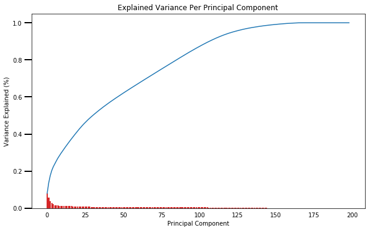

```python
# Investigate the variance accounted for by each principal component.

scree_plot(pca)
```

```python
n_components = 125
values = pca.explained_variance_ratio_
cumulative_values = np.cumsum(values)
print("With {} components, {:.4f}% of the variance is explained".format(n_components, cumulative_values[n_components -1]*100))
```

```
With 125 components, 95.5428% of the variance is explained
```

```python
# Re-apply PCA to the data while selecting for number of components to retain.

n_components = 125
pca, X_pca = do_pca(azdias_imputed_scaled, n_components=n_components)
```

### Discussion 2.2: Perform Dimensionality Reduction

The scree plot depicts both a line chart showing the cumulative variance explained and a bar chart showing the variance explained by each principal component. There is an elbow in the line chart after the inclusion of approximately 125 components, suggesting that the amount of variance explained by later components to very minimal. In fact, the use of 125 components sufficiently explained 95.5% of the variance in the dataset. Hence, only 125 compoenents was retained for this analysis.

### Step 2.3: Interpret Principal Components

Now that we have our transformed principal components, it's a nice idea to check out the weight of each variable on the first few components to see if they can be interpreted in some fashion.

As a reminder, each principal component is a unit vector that points in the direction of highest variance (after accounting for the variance captured by earlier principal components). The further a weight is from zero, the more the principal component is in the direction of the corresponding feature. If two features have large weights of the same sign (both positive or both negative), then increases in one tend expect to be associated with increases in the other. To contrast, features with different signs can be expected to show a negative correlation: increases in one variable should result in a decrease in the other.

- To investigate the features, you should map each weight to their corresponding feature name, then sort the features according to weight. The most interesting features for each principal component, then, will be those at the beginning and end of the sorted list. Use the data dictionary document to help you understand these most prominent features, their relationships, and what a positive or negative value on the principal component might indicate.
- You should investigate and interpret feature associations from the first three principal components in this substep. To help facilitate this, you should write a function that you can call at any time to print the sorted list of feature weights, for the *i*-th principal component. This might come in handy in the next step of the project, when you interpret the tendencies of the discovered clusters.

```python
def sort_pca_components(full_df, pca, nth_comp, top_n_feat=None):
    """
    Sort the pca component weights for a specified PCA component and return the features
    with the highest positive weights and the lowest negative weights
    INPUTS:
        dull_df - the dataframe before PCA transformation
        pca - the pca fitted to the dataframe
        nth_comp - the nn^th component of the PCA to be analyzed
        top_n_feat - the number of features to be returned
    OUTPUTS:
        top_pos_comp - the features of the n^th PCA component with the highest positive weights
        top_neg_comp - the features of the n^th PCA component with the lowest negative weights
    """

    # Get the index position of the nth_comp specified. Index starts at 0
    dimension = nth_comp - 1
    # get all pca component weights for this dimension and reshape to a single row
    pca_comp_weights = pca.components_[dimension].reshape(1, len(pca.components_[dimension]))

    # Put the pca components into a dataframe
    components = pd.DataFrame(np.round(pca_comp_weights, 4), columns = full_df.keys())
    index = ["Dimension "+str(nth_comp)]
    components.index = index

    # Sort the components dataframe by the top n largest positive weights
    top_pos_comp = components.sort_values(by=index, ascending=False, axis=1)

    # Sort the components dataframe by the top n largest negative weights
    top_neg_comp = components.sort_values(by=index, ascending=True, axis=1)

    if top_n_feat != None:
        top_pos_comp = top_pos_comp.iloc[:,:top_n_feat]
        top_neg_comp = top_neg_comp.iloc[:,:top_n_feat]

    return top_pos_comp, top_neg_comp
```

```python
def plot_top_pca_weights(pos_df, neg_df):
    # Plot the feature weights as a function of the components
    pos_df = pos_df.transpose()
    pos_df.plot(kind = 'bar', legend=False);
    plt.xlabel(str(pos_df.columns.values[0])+" Features")
    plt.ylabel("Feature Weight");
    plt.title("Features w/ Highest Positive Weights For Dimension "+str(pos_df.columns.values[0]));

    neg_df = neg_df.transpose()
    neg_df.plot(kind = 'bar', legend=False);
    plt.xlabel(str(pos_df.columns.values[0])+" Features")
    plt.ylabel("Feature Weight");
    plt.title("Features w/ Lowest Negative Weights For Dimension "+str(pos_df.columns.values[0]));
```

```python
# Map weights for the first principal component to corresponding feature names
# and then print the linked values, sorted by weight.
# HINT: Try defining a function here or in a new cell that you can reuse in the
# other cells.

nth_comp = 1
top_pos_comp, top_neg_comp = sort_pca_components(azdias_imputed_scaled, pca, nth_comp, 15)
print("Top positive weights for first component")
top_pos_comp
```

```
Top positive weights for first component
```

|  | LP_STATUS_GROB_1.0 | PLZ8_ANTG3 | CAMEO_INTL_2015_WEALTH | HH_EINKOMMEN_SCORE | PLZ8_ANTG4 | ORTSGR_KLS9 | EWDICHTE | FINANZ_HAUSBAUER | WOHNLAGE_URBAN | LP_STATUS_FEIN_1.0 | KBA05_ANTG4 | PLZ8_ANTG2 | ARBEIT | ANZ_HAUSHALTE_AKTIV | PLZ8_BAUMAX_COMM |
| --- | --- | --- | --- | --- | --- | --- | --- | --- | --- | --- | --- | --- | --- | --- | --- |
| Dimension 1 | 0.1921 | 0.1835 | 0.1827 | 0.1799 | 0.1779 | 0.1613 | 0.1585 | 0.1475 | 0.1387 | 0.1284 | 0.1261 | 0.1253 | 0.1175 | 0.1144 | 0.1129 |

```python
print("Top negative weights for first component")
top_neg_comp
```

```
Top negative weights for first component
```

|  | MOBI_REGIO | KBA05_ANTG1 | PLZ8_ANTG1 | FINANZ_MINIMALIST | KBA05_GBZ | KONSUMNAEHE | PLZ8_GBZ | INNENSTADT | WOHNLAGE_RURAL | LP_STATUS_GROB_4.0 | LP_STATUS_FEIN_9.0 | CAMEO_INTL_2015_LIFE_STAGE | LP_STATUS_GROB_5.0 | LP_STATUS_FEIN_10.0 | BALLRAUM |
| --- | --- | --- | --- | --- | --- | --- | --- | --- | --- | --- | --- | --- | --- | --- | --- |
| Dimension 1 | -0.2014 | -0.1879 | -0.1832 | -0.1811 | -0.1793 | -0.1374 | -0.1344 | -0.1306 | -0.1179 | -0.1117 | -0.1091 | -0.1073 | -0.1061 | -0.1061 | -0.0989 |

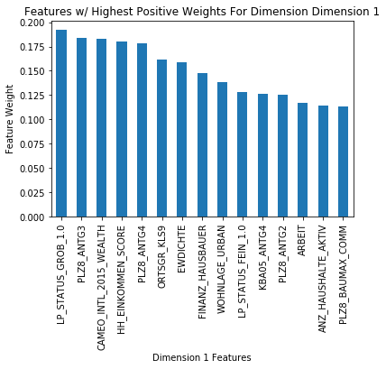

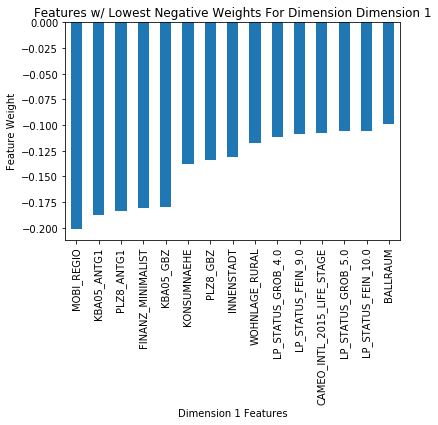

```python
plot_top_pca_weights(top_pos_comp, top_neg_comp)
```

```python
variance_explained = pca.explained_variance_ratio_[nth_comp - 1]
print("The first component explains {:.4f}% of the variance".format(variance_explained*100))
```

```
The first component explains 8.0278% of the variance
```

```python
# Map weights for the second principal component to corresponding feature names
# and then print the linked values, sorted by weight.

nth_comp = 2
top_pos_comp, top_neg_comp = sort_pca_components(azdias_imputed_scaled, pca, nth_comp, 15)
print("Top positive weights for second component")
top_pos_comp
```

```
Top positive weights for second component
```

|  | ALTERSKATEGORIE_GROB | FINANZ_VORSORGER | ZABEOTYP_3 | SEMIO_ERL | SEMIO_LUST | RETOURTYP_BK_S | W_KEIT_KIND_HH | CJT_GESAMTTYP_2.0 | FINANZ_MINIMALIST | FINANZTYP_2 | FINANZTYP_5 | LP_STATUS_FEIN_1.0 | FINANZ_HAUSBAUER | SHOPPER_TYP_3.0 | SEMIO_KRIT |
| --- | --- | --- | --- | --- | --- | --- | --- | --- | --- | --- | --- | --- | --- | --- | --- |
| Dimension 2 | 0.2358 | 0.2217 | 0.1995 | 0.1857 | 0.1652 | 0.154 | 0.1217 | 0.1104 | 0.0967 | 0.0961 | 0.0952 | 0.0877 | 0.0785 | 0.0766 | 0.0762 |

```python
print("Top negative weights for second component")
top_neg_comp
```

```
Top negative weights for second component
```

|  | PRAEGENDE_JUGENDJAHRE_DECADE | FINANZ_SPARER | SEMIO_REL | FINANZ_UNAUFFAELLIGER | SEMIO_TRADV | SEMIO_PFLICHT | FINANZ_ANLEGER | SEMIO_KULT | SEMIO_RAT | ONLINE_AFFINITAET | SEMIO_FAM | FINANZTYP_1 | SEMIO_MAT | ZABEOTYP_4 | LP_STATUS_FEIN_2.0 |
| --- | --- | --- | --- | --- | --- | --- | --- | --- | --- | --- | --- | --- | --- | --- | --- |
| Dimension 2 | -0.2397 | -0.2316 | -0.2198 | -0.2164 | -0.2096 | -0.2082 | -0.2038 | -0.1713 | -0.1683 | -0.1561 | -0.1416 | -0.1365 | -0.1353 | -0.1063 | -0.0974 |

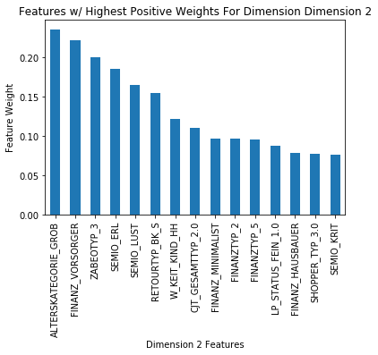

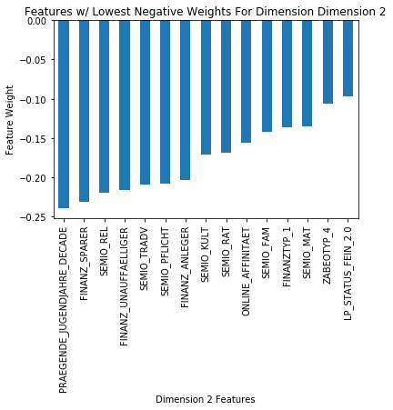

```python
plot_top_pca_weights(top_pos_comp, top_neg_comp)
```

```python
variance_explained = pca.explained_variance_ratio_[nth_comp - 1]
print("The second component explains {:.4f}% of the variance".format(variance_explained*100))
```

```
The second component explains 5.6243% of the variance
```

```python
# Map weights for the third principal component to corresponding feature names
# and then print the linked values, sorted by weight.

nth_comp = 3
top_pos_comp, top_neg_comp = sort_pca_components(azdias_imputed_scaled, pca, nth_comp, 15)
print("Top positive weights for third component")
top_pos_comp
```

```
Top positive weights for third component
```

|  | ANREDE_KZ_1 | SEMIO_VERT | SEMIO_FAM | SEMIO_SOZ | SEMIO_KULT | FINANZ_MINIMALIST | FINANZTYP_5 | SHOPPER_TYP_0.0 | ZABEOTYP_1 | SEMIO_REL | SEMIO_MAT | RETOURTYP_BK_S | W_KEIT_KIND_HH | GREEN_AVANTGARDE | ORTSGR_KLS9 |
| --- | --- | --- | --- | --- | --- | --- | --- | --- | --- | --- | --- | --- | --- | --- | --- |
| Dimension 3 | 0.3331 | 0.3047 | 0.2422 | 0.2399 | 0.2351 | 0.1272 | 0.1243 | 0.1133 | 0.1037 | 0.0977 | 0.0756 | 0.0744 | 0.0653 | 0.0599 | 0.0535 |

```python
print("Top negative weights for third component")
top_neg_comp
```

```
Top negative weights for third component
```

|  | ANREDE_KZ_2 | SEMIO_KAEM | SEMIO_DOM | SEMIO_KRIT | SEMIO_ERL | SEMIO_RAT | FINANZ_ANLEGER | FINANZTYP_1 | SHOPPER_TYP_2.0 | LP_STATUS_FEIN_2.0 | LP_STATUS_FEIN_4.0 | ZABEOTYP_4 | FINANZ_SPARER | FINANZ_HAUSBAUER | PRAEGENDE_JUGENDJAHRE_MOVEMENT |
| --- | --- | --- | --- | --- | --- | --- | --- | --- | --- | --- | --- | --- | --- | --- | --- |
| Dimension 3 | -0.3331 | -0.3014 | -0.2698 | -0.2497 | -0.1898 | -0.1572 | -0.1467 | -0.0995 | -0.0837 | -0.0779 | -0.064 | -0.0591 | -0.0586 | -0.0585 | -0.0576 |

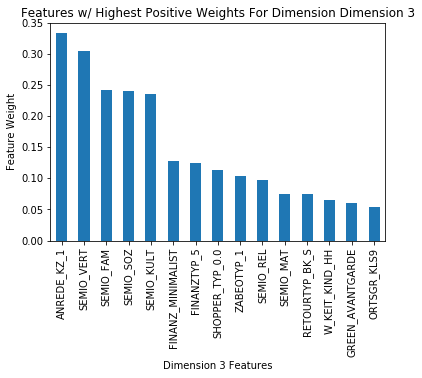

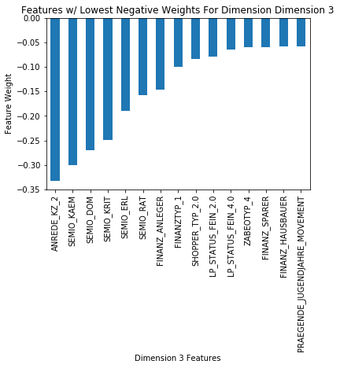

```python
plot_top_pca_weights(top_pos_comp, top_neg_comp)
```

```python
variance_explained = pca.explained_variance_ratio_[nth_comp - 1]
print("The third component explains {:.4f}% of the variance".format(variance_explained*100))
```

```
The third component explains 3.8735% of the variance
```

### Discussion 2.3: Interpret Principal Components

The first principal component explained 8.0278% of the variance in the data set and the component's top 10 positive and negative features by weight are:

| Top 10 Positive Features | Top 10 Negative Features |
| --- | --- |
| 1. LP_STATUS_GROB_1.0: Social status, where 1 indicates low income earners | 1. MOBI_REGIO: Movement Patterns, where lower values are associated with very high movement patterns |
| 2. PLZ8_ANTG3: High share of 6-8 family homes in PL8 region | 2. KBA05_ABTG1: Number of 1-2 family homes in microcell. Low values for this feature indicate lower share of 1-2 family homes in microcell |
| 3. CAMEO_INTL_2015_WEALTH: Wealth, where higher values are associated with the less affluent | 3. PLZ8_ANTG1: Number of 1-2 family houses in the PLZ8 region. Lower values indicate lower share of 1-2 family homes in the PL8 region |
| 4. HH_EINKOMMEN_SCORE: Estimated household net income, where higher values are associated with lower net income | 4. FINANZ_MINIMALIST: Financial typology for the trait of low financial interest, where lower values are associated with very high scores for low financial interest |
| 5. PLZ8_ANTG4: Very high share of 10+ family homes in PL8 region | 5. KBA05_GBZ: Number of buildings in the microcell, where lower values are associated with fewer buildings in the microcell |
| 6. ORTSGR_KLS9: Size of community, 9 means > 700,000 inhabitants | 6. KONSUMNAEHE: Distance from building to point of sale, where lower values are associated with smaller distances |
| 7. EWDICHTE: Density of household per square kilometer, where higher values correspond to higher density | 7. PLZ8_GBZ: Number of buildings in the PLZ8 region, where lower values are associated with fewer buildings |
| 8. FINANZ_HAUSBAUER: Financial typology for the trait home ownership, where higher values are associated with lower homeownership rates | 8. INNENSTADT: Distance to city center, where lower values are associated with smaller distance to the city center |
| 9. WOHNLAGE_URBAN: Neighborhood quality for urban areas, where higher values are associated with poorer quality | 9. WOHNLAGE_RURAL: Neighborhood quality, where 0 indicates that the person resides in an urban area. Hence lower scores suggest that the person is less likely to live in rural areas |
| 10. LP_STATU_FLEIN_1.0: Social status, where a value of 1 indicates typical low income earners | 10. LP_STATUS_GROB_4.0: A rough scale of social status, where a value of 4 indicates a status of homeowners. Lower values for this feature indicate lower probability of being a homeowner |

By observing the table, we conclude that the first principal component increases with:

1. decrease in income levels (LP_STATUS_GROB_1.0, CAMEO_INTL_2015_WEALTH, HH_EINKOMMEN_SCORE and LP_STATUS_FLEIN_1.0)
2. incease in the population density of the residential area (OSTGR_KLS9 and EWICHTE)
3. decrease in the quality of the neighbourhood (WOHNLAGE_URBAN)
4. decrease in homeownership rate (FINANZ_HAUSBAUER and LP_STATUS_GROB_4.0)
5. increase in the number of family homes with more than 6 members (PLZ8_ANTG3 and PLZ8_ANTG4).
6. decrease in movement patterns (MOBI_REGIO)
7. decrease in number of family homes with 1-2 members (KBA05_ABTG1 and PLZ8_ANTG1)
8. increase in score for low financial interest
9. decrease in the number of buildings in the microcell and PLZ8 region (KBA05_GBZ and PLZ8_GBZ)
10. decrease in the distance to the point of sale (KONSUMNAEHE)
11. decrease in the distance to city center
12. decrease in likelihood of living in rural area

Hence, it is likely that this component focuses on lower income individuals who reside in densely populated urban area near the downtown core in neighbourhoods of poorer quality. In addition, these individuals are less likely to own homes and are more likely to live in households with larger family sizes (>6 members). Since they also more likely to live in areas with fewer buidlings, this indicates that the first principle component is mostly capturing the group of people who living in areas with a small number of large rental apartment buildings. Finally, these individuals are less likely to be interest in financial products and services.

The second principal component explained 5.6243% of the variance in the data set, and the component's top 10 positive and negative features by weight are:

| Top 10 Positive Features | Top 10 Negative Features |
| --- | --- |
| 1. ALTERSKATEGORIE_GROB: Estimated age where higher values are indicate older age | 1. PRAEGENDE_JUGENDJAHRE_DECADE: Dominating decade of individual's youth, where lower values are associated with earlier decades (1940s and 1950s) |
| 2. FINANZ_VORSORGER: Financial preparedness, where higher values indicate lower preparedness levels | 2. FINANZ_SPARER: Financial typology for trait of money saver, where lower scores indicate very high scores for being a money saver |
| 3. ZABEOTYP_3: Energy consumption, where a value of 3 indicates a fair supply of energy | 3. SEMIO_REL: Personality type (religious), where lower values indicate higher affinity for being religious |
| 4. SEMIO_ERL: Personality type (event-oriented), where higher values are associated with lower affinity for events | 4. FINANZ_UNAUFFAELLIGER: Financial typology (inconspicuous), where lower values indicate very high scores for being financially inconspicuous, meaning this individual is less likely to engage in flas… |
| 5. SEMIO_LUST: Personality type (sensual-minded), where higher values indicate lower affinity for being sensual-minded | 5. SEMIO_TRADV: Personality typology (traditional-minded), where lower values indicate higher scores for being traditional-minded |
| 6. RETOURTYP_BK_S: Return type, where higher values are associated with individuals who return fewer purchased products | 6. SEMIO_PFLICHT: Personality type (dutiful), where lower scores are indicative of higher affinity for being dutiful |
| 7. W_KEIT_KIND_HH: Likelihood of children in household, where higher values are associated with lower likelihood of having children | 7. FINANZ_ANLEGER: Financial typology (investor), where lower values are indicative of higher scores of being an investor |
| 8. CJT_GESAMTTYP_2.0: Customer-Journey-Typology which tracks preferred information and buying channels for consumer. A value of 2 indicates advertising and consumption traditionalist | 8. SEMIO_KULT: Personality typology (cultural-minded), where lower scores indicate higher scores for being culturally minded |
| 9. FINANZ_MINIMALIST: Financial typology for the trait of low financial interest, where higher values are associated with very low scores for low financial interest | 9. SEMIO_RAT: Personality typology (rational), where lower scores indicate higher scores for being rational |
| 10. FINANZTYP_2: Money-saver financial type | 10. ONLINE_AFFINITAET: Online affinity, where lower scores indicate lower affinity for online presence |

In summary, the second principal component increases with:

1. increase in age (ALTERSKATEGORIE_GROB)
2. decrease in financial preparedness and financial interest (FINANZ_VORSORGER and FINANZ_MINIMALIST)
3. increase in fair supply of energy (ZABEOTYP_3)
4. decrease in event-oriented and sensual-mindedness personality types (SEMIO_ERL and SEMIO_LUST)
5. decrease in returning purchases (RETOURTYP_BK_S)
6. decrease in the likelihood of children in the household (W_KEIT_KIND_HH)
7. increase in preference for traditional means of advertising and traditional channels for good purchases, eg) physical stores (CJT_GESAMTTYP_2.0)
8. increase in probability of being a money saver (FINANZTYP_2.0 and FINANZ_SPARER)
9. increase in probability of growing up in the earlier decades (PRAEGENDE_JUGENDJAHRE_DECADE)
10. increase in affinity for being religious, traditional-minded, dutiful, cultural-minded and rational (SEMIO_REL, SEMIO_TRADV, SEMIO_PFLICHT, SEMIO_KULT and SEMIO_RAT)
11. increase in probability of being financially inconspicuous, eg) less likely to make flashy purchases. (FINANZ_UNAUFFAELLIGER)
12. increase in probability of being an investor (FINANZ_ANLEGER)
13. decrease in affinity of online presence (ONLINE_AFFINITAET)

Hence, this component focues on older individuals who grew up in the earlier decades (40s, 50s, 60s) and who are less interested in attending events and being sensual minded. In addition, these individuals are more likely to religious, traditional-minded, dutiful, cultural-minded and rational. They are less likely to surf the web and engage in online shopping and they show a preference for shopping in brick and mortar stores. Even though they are less financially prepared and less financially interested, they are more likely to save money and are more willing to invest. They also abstain from making flashy purchases.

The third principle component explained 3.8735% of the variance in the data set, and the component's top 10 positive and negative features by weight are

| Top 10 Positive Features | Top 10 Negative Features |
| --- | --- |
| 1. ANREDE_KZ_1: Male. Higher score indicate more likely to be male | 1. ANREDE_KZ_2: Female. Lower values indicate less likely to be female |
| 2. SEMIO_VERT: Personality type (dreamful), where higher values indicate lower affinity for being dreamful | 2. SEMIO_KAEM: Personality type (combative attitude), where lower values indicate higher affinity to being combatively minded |
| 3. SEMIO_FAM: Personality type (family-minded), where higher values indicate lower affinity for being family minded | 3. SEMIO_DOM: Personality type (dominant-minded), where lower values indicate higher affinity for being dominant-minded |
| 4. SEMIO_SOZ: Personality type (socially-minded), where higher values indicate lower affinity for being socially-minded | 4. SEMIO_KRIT: Personality type (critical-minded), where lower values indicate higher affinity for being critical-minded |
| 5. SEMIO_KULT: Personality type (cultural-minded), where higher values indicate lower affinity for being cultural-minded | 5. SEMIO_ERL: Personality type (event-oriented), where lower values indicate higher affinity for being event-oriented |
| 6. FINANZ_MINIMALIST: Financial typology (low financial interest), where higher values indicate lower probability of having low financial interest | 6. SEMIO_RAT: Personality type (rational), where lower values indicate higher affinity for being rational |
| 7. FINANZTYP_5: Financial type (investor), where higher values indicate higher probability of being classified as an investor as compared to other financial types | 7. FINANZ_ANLEGER: Financial typology (investor), where lower values indicate higher affinity for being an investor |
| 8. SHOPPER_TYP_0.0: Shopper typology (external-supplied hedonist), where higher values indicate higher probability of being a hedonist shopper, one that shops for fun, entertainment and satisfaction r… | 8. FINANZTYP_1: Financial type (low financial interest), where lower values indicate lower probability of being having low financial interest |
| 9. ZABEOTYP_1: Energy consumption typology (green), where higher values indicate higher preference for green energy | 9. SHOPPER_TYP_2.0: Shopper typology (family-shopper), where lower values indicate lower probability of shopping for family needs |
| 10. SEMIO_REL: Personality type (religious), where higher values indicate lower affinity for being religious | 10. LP_STATUS_FEIN_2.0: Social status (orientation-seeking low-income earners), where lower values indicate lower probability of being an orientation-seeking low-income earner |

In summary, the third principal component increases with:

1. being male (ANREDE_KZ_1 and ANREDE_KZ_2)
2. decrease in being dreamful, family-minded, socially-minded, cultural-minded and religious (SEMIO_VERT, SEMIO_FAM, SEMIO_SOZ, SEMIO_KULT and SEMIO_REL)
3. increase in having a combative attitude and being more rational, dominant-minded, critical-minded and event-oriented (SEMIO_KAEM, SEMIO_DOM, SEMIO_KRIT, SEMIO_ERL and SEMIO_RAT)
4. increase in financial interest (FINANZ_MINIMALIST and FINANZTYP_1)
5. increase in the probability of being an investor (FINANZTYP_5 and FINANZ_ANLEGER)
6. increase in probabillity of being a hedonist shopper (SHOPPER_TYP_0.0)
7. decrease in probability of being a family-shopper (SHOPPER_TYP_2.0)
8. increase in usage of green energy (ZABEOTYP_1)
9. decrease in probability of having a low-income status

Hence, the component seems to be capturing males who are perhaps young and single and have relatively good income. These group of individuals tend to shop for fun, entertainment and satisfaction rather than for family needs. They also have a preference of consuming green energy. In addition, they are generally less dreamful, family-minded, socially-minded, cultural-minded and religious, while being more rational, dominant-minded and critical-minded. They like to attend events, and they also have a tendency for being combative.

## Step 3: Clustering

### Step 3.1: Apply Clustering to General Population

You've assessed and cleaned the demographics data, then scaled and transformed them. Now, it's time to see how the data clusters in the principal components space. In this substep, you will apply k-means clustering to the dataset and use the average within-cluster distances from each point to their assigned cluster's centroid to decide on a number of clusters to keep.

- Use sklearn's KMeans class to perform k-means clustering on the PCA-transformed data.
- Then, compute the average difference from each point to its assigned cluster's center. **Hint**: The KMeans object's `.score()` method might be useful here, but note that in sklearn, scores tend to be defined so that larger is better. Try applying it to a small, toy dataset, or use an internet search to help your understanding.
- Perform the above two steps for a number of different cluster counts. You can then see how the average distance decreases with an increasing number of clusters. However, each additional cluster provides a smaller net benefit. Use this fact to select a final number of clusters in which to group the data. **Warning**: because of the large size of the dataset, it can take a long time for the algorithm to resolve. The more clusters to fit, the longer the algorithm will take. You should test for cluster counts through at least 10 clusters to get the full picture, but you shouldn't need to test for a number of clusters above about 30.
- Once you've selected a final number of clusters to use, re-fit a KMeans instance to perform the clustering operation. Make sure that you also obtain the cluster assignments for the general demographics data, since you'll be using them in the final Step 3.3.

```python
def get_kmeans_avg_dist(data, n_clusters):
    '''
    returns the kmeans score regarding SSE for points to centers
    INPUTS:
        data - the dataset you want to fit kmeans to
        n_clusters - the number of clusters you want (the k value)
    OUTPUTS:
        avg_dist - the average distance from each point to their assigned centroid
    '''
    #instantiate kmeans
    kmeans = KMeans(n_clusters=n_clusters, random_state=0)

    # Then fit the model to your data using the fit method
    model = kmeans.fit(data)

    # Obtain a score related to the model fit
    # This is the total distance from each point to their assigned centroid (SSE)
    score = np.abs(model.score(data))

    # Get the average distance from each point to their assigned centroid
    avg_dist = score / data.shape[0]

    return avg_dist
```

```python
# Over a number of different cluster counts...
k_s = np.arange(1,11)
avg_distances = []
for k in k_s:
    #print("Cluster: "+str(k))
    # run k-means clustering on the data and...
    avg_dist = get_kmeans_avg_dist(X_pca, k)
    avg_distances.append(avg_dist)
    print("Cluster: {} ... Average distance: {:.4f}".format(k, avg_dist))
    # compute the average within-cluster distances.
```

```
Cluster: 1 ... Average distance: 190.1226
Cluster: 2 ... Average distance: 177.7940
Cluster: 3 ... Average distance: 172.2653
Cluster: 4 ... Average distance: 168.4427
Cluster: 5 ... Average distance: 165.3538
Cluster: 6 ... Average distance: 163.1394
Cluster: 7 ... Average distance: 161.6516
Cluster: 8 ... Average distance: 159.7849
Cluster: 9 ... Average distance: 158.7147
Cluster: 10 ... Average distance: 156.8445
```

```python
k_s = np.arange(11,16)
avg_distances = []
for k in k_s:
    avg_dist = get_kmeans_avg_dist(X_pca, k)
    avg_distances.append(avg_dist)
    print("Cluster: {} ... Average distance: {:.4f}".format(k, avg_dist))
```

```
Cluster: 11 ... Average distance: 155.7736
Cluster: 12 ... Average distance: 155.0931
Cluster: 13 ... Average distance: 153.6881
Cluster: 14 ... Average distance: 153.1966
Cluster: 15 ... Average distance: 152.0391
```

```python
k_s = np.arange(16,21)
avg_distances = []
for k in k_s:
    avg_dist = get_kmeans_avg_dist(X_pca, k)
    avg_distances.append(avg_dist)
    print("Cluster: {} ... Average distance: {:.4f}".format(k, avg_dist))
```

```
Cluster: 16 ... Average distance: 151.1491
Cluster: 17 ... Average distance: 150.3920
Cluster: 18 ... Average distance: 149.6656
Cluster: 19 ... Average distance: 149.0810
Cluster: 20 ... Average distance: 147.9248
```

```python
k_s = np.arange(21,26)
avg_distances = []
for k in k_s:
    avg_dist = get_kmeans_avg_dist(X_pca, k)
    avg_distances.append(avg_dist)
    print("Cluster: {} ... Average distance: {:.4f}".format(k, avg_dist))
```

```
Cluster: 21 ... Average distance: 147.1237
Cluster: 22 ... Average distance: 146.1378
Cluster: 23 ... Average distance: 145.4344
Cluster: 24 ... Average distance: 144.8772
Cluster: 25 ... Average distance: 144.2136
```

```python
k_s = np.arange(26,31)
avg_distances = []
for k in k_s:
    avg_dist = get_kmeans_avg_dist(X_pca, k)
    avg_distances.append(avg_dist)
    print("Cluster: {} ... Average distance: {:.4f}".format(k, avg_dist))
```

```
Cluster: 26 ... Average distance: 143.9176
Cluster: 27 ... Average distance: 142.5278
Cluster: 28 ... Average distance: 142.3645
Cluster: 29 ... Average distance: 141.1868
Cluster: 30 ... Average distance: 139.9115
```

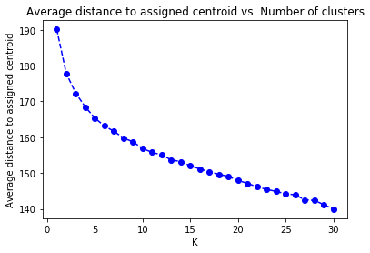

```python
# Investigate the change in within-cluster distance across number of clusters.
# HINT: Use matplotlib's plot function to visualize this relationship.
k_s = np.arange(1,31)
avg_distances = [190.1226,177.7940,172.2653,168.4427,165.3538,\
                 163.1394,161.6516,159.7849,158.7147,156.8445,\
                 155.7736,155.0931,153.6881,153.1966,152.0391,\
                 151.1491,150.3920,149.6656,149.0810,147.9248,\
                 147.1237,146.1378,145.4344,144.8772,144.2136,
                 143.9176,142.5278,142.3645,141.1868,139.9115
                ]
plt.plot(k_s, avg_distances, linestyle='--', marker='o', color='b');
plt.xlabel('K');
plt.ylabel('Average distance to assigned centroid');
plt.title('Average distance to assigned centroid vs. Number of clusters');
```

```python
print("Number of samples in the general population")
azdias_imputed_scaled.shape[0]
```

```
797837
```

```python
# Create dictionary of number of clusters vs the decrease in average distance to assigned centroid
clusters = np.arange(2,31)
distance_decrease = np.diff(avg_distances)
distance_decrease = np.around(distance_decrease, decimals=4)
distance_decrease = dict(zip(clusters,distance_decrease))
print(distance_decrease)
```

```
{2: -12.3286, 3: -5.5286999999999997, 4: -3.8226, 5: -3.0889000000000002, 6: -2.2143999999999999, 7: -1.4878, 8: -1.8667, 9: -1.0702, 10: -1.8702000000000001, 11: -1.0709, 12: -0.68049999999999999, 13: -1.405, 14: -0.49149999999999999, 15: -1.1575, 16: -0.89000000000000001, 17: -0.7571, 18: -0.72640…
```

```python
# Can try silhouette score as well
def get_kmeans_score(data, n_clusters):
    #instantiate kmeans
    kmeans = KMeans(n_clusters=n_clusters, random_state=0)

    # Then fit the model to your data using the fit method
    preds = kmeans.fit_predict(data)
    # Use smaller samples to prevent memeory error
    #score = silhouette_score(data,preds)
    score = silhouette_score(data,preds,sample_size=20000,random_state=0)
    print("Cluster: {} ... Silhouette Score: {:.4f}".format(k, score))
    return score
```

```python
k_s = np.arange(2,6)
scores = []
for k in k_s:
    # run k-means clustering on the data and...
    score = get_kmeans_score(X_pca, k)
    scores.append(score)
```

```
Cluster: 2 ... Silhouette Score: 0.0649
Cluster: 3 ... Silhouette Score: 0.0426
Cluster: 4 ... Silhouette Score: 0.0411
Cluster: 5 ... Silhouette Score: 0.0416
```

```python
k_s = np.arange(6,11)
scores = []
for k in k_s:
    # run k-means clustering on the data and...
    score = get_kmeans_score(X_pca, k)
    scores.append(score)
```

```
Cluster: 6 ... Silhouette Score: 0.0355
Cluster: 7 ... Silhouette Score: 0.0326
Cluster: 8 ... Silhouette Score: 0.0346
Cluster: 9 ... Silhouette Score: 0.0360
Cluster: 10 ... Silhouette Score: 0.0314
```

```python
k_s = np.arange(11,16)
scores = []
for k in k_s:
    # run k-means clustering on the data and...
    score = get_kmeans_score(X_pca, k)
    scores.append(score)
```

```
Cluster: 11 ... Silhouette Score: 0.0320
Cluster: 12 ... Silhouette Score: 0.0320
Cluster: 13 ... Silhouette Score: 0.0344
Cluster: 14 ... Silhouette Score: 0.0361
Cluster: 15 ... Silhouette Score: 0.0319
```

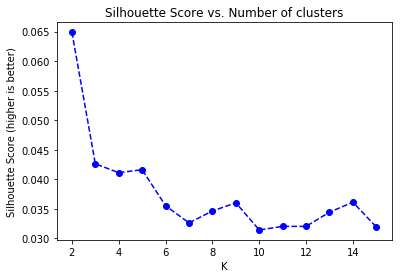

```python
k_s=np.arange(2,16)
scores=[0.0649,0.0426,0.0411,0.0416,\
        0.0355,0.0326,0.0346,0.0360,0.0314,\
        0.0320,0.0320,0.0344,0.0361,0.0319
       ]
plt.plot(k_s, scores, linestyle='--', marker='o', color='b');
plt.xlabel('K');
plt.ylabel('Silhouette Score (higher is better)');
plt.title('Silhouette Score vs. Number of clusters');
```

```python
# Re-fit the k-means model with the selected number of clusters and obtain
# cluster predictions for the general population demographics data.
n_clusters = 5
kmeans = KMeans(n_clusters=n_clusters, random_state=0)
preds = kmeans.fit_predict(X_pca)
```

### Discussion 3.1: Apply Clustering to General Population

To determine the appropriate number of clusters, a scree plot was made depicting the average distance to the assigned centroid vs the number of clusters. The scree plot did not depict a definite elbow, and the addition of more clusters always resulted in consistent decreases in the average distance to the assigned centroid. However, the biggest benefits from adding additional clusters seemed to stop after 6 clusters were used. The subsequent addition of more clusters yielded a decrease of less than 2 in the average distance to the assigned centroid.

In order to help determine the appropriate number of clusters, the Silhouette Coefficients was plotted against the number of clusters used. Because the computation of the coefficients was an intensive process, the coefficients were only calculated from a much smaller random sample of the data (20,000 sample from the original 797,837). Since only a small sample was used, the Silhouette Coefficient will only be used to affirm the results from the scree plot of the average distances. The Silhouette Coefficient measures how similar an object is to its own cluster as compared to other clusters, and the higher the coefficient, the more well-matched an object is to its own cluster and the more poorly matched it is to its neighboring clusters. In general, the higher the coefficient the better the clusters would be. It was apparent that the highest coefficient was achieved with 2 clusters. Since we still received relatively huge benefits from increasing the number of clusters beyond 2, the ideal number of clusters seemed to be 5. Increasing the number of clusters beyond 5 resulted in a decrease in the Silhouette Coefficients. The coefficients never exceeded 0.04 after 5 clusters. Hence, the ideal number of clusters is 5 since it resulted in relatively high decreases in average distance to the assigned centroids and high Sihouette Coefficients.

### Step 3.2: Apply All Steps to the Customer Data

Now that you have clusters and cluster centers for the general population, it's time to see how the customer data maps on to those clusters. Take care to not confuse this for re-fitting all of the models to the customer data. Instead, you're going to use the fits from the general population to clean, transform, and cluster the customer data. In the last step of the project, you will interpret how the general population fits apply to the customer data.

- Don't forget when loading in the customers data, that it is semicolon (`;`) delimited.
- Apply the same feature wrangling, selection, and engineering steps to the customer demographics using the `clean_data()` function you created earlier. (You can assume that the customer demographics data has similar meaning behind missing data patterns as the general demographics data.)
- Use the sklearn objects from the general demographics data, and apply their transformations to the customers data. That is, you should not be using a `.fit()` or `.fit_transform()` method to re-fit the old objects, nor should you be creating new sklearn objects! Carry the data through the feature scaling, PCA, and clustering steps, obtaining cluster assignments for all of the data in the customer demographics data.

```python
# Load in the customer demographics data.
customers = pd.read_csv('Udacity_CUSTOMERS_Subset.csv', sep=';')
print(customers.head())
```

```
   AGER_TYP  ALTERSKATEGORIE_GROB  ANREDE_KZ  CJT_GESAMTTYP  \
0         2                     4          1            5.0
1        -1                     4          1            NaN
2        -1                     4          2            2.0
3         1                     4          1            2.0
4        -1                     3          1            6.0

   FINANZ_MINIMALIST  FINANZ_SPARER  FINANZ_VORSORGER  FINANZ_ANLEGER  \
0                  5              1                 5               1
1                  5              1                 5               1
2                  5              1                 5               1
3                  5              1                 5               2
4                  3              1                 4               4

   FINANZ_UNAUFFAELLIGER  FINANZ_HAUSBAUER    ...     PLZ8_ANTG1  PLZ8_ANTG2  \
```

[output cut: 21 more lines]

```python
# Apply preprocessing, feature transformation, and clustering from the general
# demographics onto the customer data, obtaining cluster predictions for the
# customer demographics data.

# Clean data
customers_cleaned, customers_outlier = clean_data(customers, feat_info, removed_columns, all_var_to_be_encoded)
```

```python
# append any columns present in the population datset but not in customer dataset, to the customer dataset for dimension to match
for col in azdias_cleaned_dummies_eng.columns.values:
    if col not in customers_cleaned.columns.values:
        col_pos = azdias_cleaned_dummies_eng.columns.get_loc(col)
        print("Adding column: "+str(col))
        customers_cleaned.insert(col_pos, col, 0)
```

```
Adding column: GEBAEUDETYP_5.0
```

```python
# Impute missing values
customers_imputed = pd.DataFrame(imp.transform(customers_cleaned))
customers_imputed.columns = customers_cleaned.columns
customers_imputed.index = customers_cleaned.index

# Perform feature scaling
customers_imputed_scaled = pd.DataFrame(ss.transform(customers_imputed))
customers_imputed_scaled.columns = customers_cleaned.columns
customers_imputed_scaled.index = customers_cleaned.index
```

```python
# PCA transformations
customers_pca = pca.transform(customers_imputed_scaled)

# Apply clusterings
customers_preds = kmeans.predict(customers_pca)
```

### Step 3.3: Compare Customer Data to Demographics Data

At this point, you have clustered data based on demographics of the general population of Germany, and seen how the customer data for a mail-order sales company maps onto those demographic clusters. In this final substep, you will compare the two cluster distributions to see where the strongest customer base for the company is.

Consider the proportion of persons in each cluster for the general population, and the proportions for the customers. If we think the company's customer base to be universal, then the cluster assignment proportions should be fairly similar between the two. If there are only particular segments of the population that are interested in the company's products, then we should see a mismatch from one to the other. If there is a higher proportion of persons in a cluster for the customer data compared to the general population (e.g. 5% of persons are assigned to a cluster for the general population, but 15% of the customer data is closest to that cluster's centroid) then that suggests the people in that cluster to be a target audience for the company. On the other hand, the proportion of the data in a cluster being larger in the general population than the customer data (e.g. only 2% of customers closest to a population centroid that captures 6% of the data) suggests that group of persons to be outside of the target demographics.

Take a look at the following points in this step:

- Compute the proportion of data points in each cluster for the general population and the customer data. Visualizations will be useful here: both for the individual dataset proportions, but also to visualize the ratios in cluster representation between groups. Seaborn's [`countplot()`](https://seaborn.pydata.org/generated/seaborn.countplot.html) or [`barplot()`](https://seaborn.pydata.org/generated/seaborn.barplot.html) function could be handy.
  - Recall the analysis you performed in step 1.1.3 of the project, where you separated out certain data points from the dataset if they had more than a specified threshold of missing values. If you found that this group was qualitatively different from the main bulk of the data, you should treat this as an additional data cluster in this analysis. Make sure that you account for the number of data points in this subset, for both the general population and customer datasets, when making your computations!
- Which cluster or clusters are overrepresented in the customer dataset compared to the general population? Select at least one such cluster and infer what kind of people might be represented by that cluster. Use the principal component interpretations from step 2.3 or look at additional components to help you make this inference. Alternatively, you can use the `.inverse_transform()` method of the PCA and StandardScaler objects to transform centroids back to the original data space and interpret the retrieved values directly.
- Perform a similar investigation for the underrepresented clusters. Which cluster or clusters are underrepresented in the customer dataset compared to the general population, and what kinds of people are typified by these clusters?

```python
# Fix this to make sure that you account for the number of data points in this subset,
# for both the general population and customer datasets, when making your computations!

def get_clusters_prop(pred, num_non_outlier_clusters, outlier_df_size):
    """
    Returns dictionary of all cluster labels and the proportion of persons in each cluster
    INPUTS:
        pred - the array of label predictions
        outlier_df_size - number of rows in the outlier dataframe
    OUTPUTS:
        label_prop - dictionary of cluster labels and the proportion of persons in each cluster
    """
    # Dictionary of labels and the total counts for each label
    label_count = Counter(pred)
    total = len(pred) + outlier_df_size
    # Dictionary of labels and the proportion of total population
    label_prop = {k:v/total for k,v in label_count.items()}
    # Add outlier cluster proportion
    non_outlier_cluster_num = num_non_outlier_clusters
    label_prop[non_outlier_cluster_num] = outlier_df_size/total
    # Sort dictionary by keys (clusters)
    label_prop = {k: label_prop[k] for k in sorted(label_prop)}
    return label_prop
```

```python
def plot_clusters_histogram(pop_clusters_prop, cust_clusters_prop):
    """ Plot two histrograms side by side comparing frequency of values from both df1 and df2.
    INPUTS:
       pop_clusters_prop - dictionary of population cluster labels and the proportion of persons in each cluster
       cust_clusters_prop - dictionary of customers cluster labels and the proportion of persons in each cluster
    """
    plt.figure()
    pop_keys=list(pop_clusters_prop.keys())
    cust_keys=list(cust_clusters_prop.keys())
    pop_prop = list(pop_clusters_prop.values())
    cust_prop = list(cust_clusters_prop.values())

    bar_width = 0.4
    cust_keys = np.array(cust_keys)

    labels = np.array(pop_keys)
    labels +=1
    labels = list(labels)
    labels[-1] = "outlier"

    plt.bar(pop_keys, pop_prop, bar_width, color='r',label='General Population')
    plt.bar(cust_keys+bar_width, cust_prop, bar_width, color='b',label='Customer')
    plt.title("Clusters from General Population vs Customers Data")
    plt.xlabel("Clusters")
    plt.ylabel("Proportion")
    plt.legend()
    plt.xticks(np.arange(len(pop_keys))+0.2, labels)
```

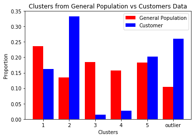

```python
# Compare the proportion of data in each cluster for the customer data to the
# proportion of data in each cluster for the general population.

pop_clusters_prop = get_clusters_prop(preds, n_clusters, azdias_above_thres.shape[0])
cust_clusters_prop = get_clusters_prop(customers_preds, n_clusters, customers_outlier.shape[0])
plot_clusters_histogram(pop_clusters_prop, cust_clusters_prop)
```

```python
# Get clusters' means
centers_pca = kmeans.cluster_centers_
```

```python
def top_clusters_means(nth_cluster,top_n=3):
    cluster_centers = centers_pca[nth_cluster - 1]
    top_ind = np.argpartition(cluster_centers, -1*top_n)[-1*top_n:]
    top_means = cluster_centers[top_ind]
    sorted_top_means_asc = np.sort(top_means)
    sorted_top_means_desc = np.flip(sorted_top_means_asc,axis=0)
    print("Top principal components of cluster "+str(nth_cluster))
    for i in range(top_n):
        mean = sorted_top_means_desc[i]
        ind = np.where(top_means == mean)
        pca_comp = top_ind[ind][0] + 1
        print("PCA component: {} ... Mean: {:.4f}".format(pca_comp,mean))
```

```python
# What kinds of people are part of a cluster that is overrepresented in the
# customer data compared to the general population?

# Fourth cluster
nth_cluster = 2
top_clusters_means(nth_cluster)
```

```
Top principal components of cluster 2
PCA component: 4 ... Mean: 3.4185
PCA component: 3 ... Mean: 0.8668
PCA component: 2 ... Mean: 0.7854
```

```python
# What kinds of people are part of a cluster that is underrepresented in the
# customer data compared to the general population?

# First cluster
nth_cluster = 1
top_clusters_means(nth_cluster)
```

```
Top principal components of cluster 1
PCA component: 2 ... Mean: 3.3365
PCA component: 1 ... Mean: 2.6449
PCA component: 3 ... Mean: 0.5105
```

```python
# Second cluster
nth_cluster = 3
top_clusters_means(nth_cluster)
```

```
Top principal components of cluster 3
PCA component: 1 ... Mean: 4.8353
PCA component: 10 ... Mean: 0.4530
PCA component: 18 ... Mean: 0.3542
```

```python
# Third cluster
nth_cluster = 4
top_clusters_means(nth_cluster)
```

```
Top principal components of cluster 4
PCA component: 6 ... Mean: 0.4779
PCA component: 9 ... Mean: 0.3986
PCA component: 38 ... Mean: 0.3408
```

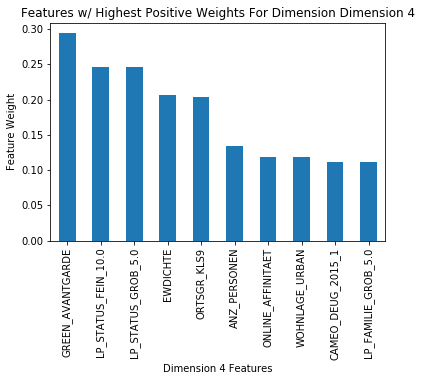

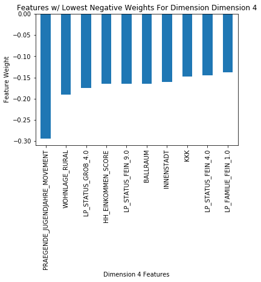

```python
# Analyze fourth PCA component
nth_comp = 4
top_pos_comp, top_neg_comp = sort_pca_components(azdias_imputed_scaled, pca, nth_comp, 10)
plot_top_pca_weights(top_pos_comp, top_neg_comp)
```

The fourth principal component's top 10 positive and negative features by weight are:

| Top 10 Positive Features | Top 10 Negative Features |
| --- | --- |
| 1. GREEN_AVANTGARDE: Membership in environmental sustainability as part of youth. Higher value indicates higher probability of being a member of environmental sustainability movement during their yout… | 1. PRAEGENDE_JUGENDJAHRE_MOVEMENT: Dominating movement of person's youth, where lower values indicate higher probability of being involved in avantgarde movement vs mainstream movement. |
| 2. LP_STATUS_FEIN_10.0: Social status fine scale (top earners). Higher values indicate higher probability of being a top earner. | 2. WOHNLAGE_RURAL: Neighborhood quality, where 0 indicates that the person resides in an urban area. Hence lower scores suggest that the person is less likely to live in rural areas. |
| 3. LP_STATUS_GROB_5.0: Social status rough scale (top earners). Higher values indicate higher probability of being a top earner. | 3. LP_STATUS_GROB_4.0: Social status rough scale (house owners). Lower values indicates lower probability of having house owners social status. |
| 4. EWDICHTE: Density of households per square kilometer. Higher values indicate higher density of household. | 4. HH_EINKOMMEN_SCORE: Estimated household net income: Lower values indicate higher household net income. |
| 5. ORTSGR_KLS9: Size of community. Higher values indicate more inhabitants. | 5. LP_STATUS_FLEIN_9.0: Social status fine scale. Lower values indicate lower probability of having house owner social status. |
| 6. ANZ_PERSONEN: Number of adults in household. Higher values indicate more adults in household. | 6. BALLRAUM: Distance to nearest urban center. Lower values indicate smaller distance to urban center. |
| 7. ONLINE_AFFINITAET: Online affinity. Higher values indicate higher affinity for internet usage. | 7. INNENSTADT: Distance to city center. Lower value indicate smaller distance to city center. |
| 8. WOHNLAGE_URBAN: Neighborhood quality for urban areas, where higher values are associated with poorer quality. | 8. KKK: Purchasing power in region. Lower values indicate higher purchasing power in region. |
| 9. CAMEO_DEUG_2015_1: Wealth/life stage typology rough scale (Upper class). Higher values indicate higher probability of being upper class. | 9. LP_STATUS_FLEIN_4.0: Social status (villagers). Lower values indicate lower probability of being a villager. |
| 10. LP_FAMILIE_GROB_5.0: Family type rough scale (multi-person household). Higher values indicate higher probability of being in a multi-person household. | 10. LP_FAMILIE_FEIN_1.0: Family type fine scale (single). Lower values indicate lower probability of being single. |

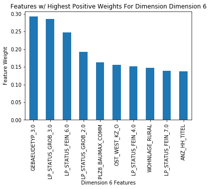

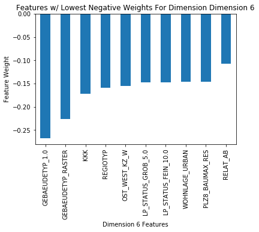

```python
# Analyze sixth component
nth_comp = 6
top_pos_comp, top_neg_comp = sort_pca_components(azdias_imputed_scaled, pca, nth_comp, 10)
plot_top_pca_weights(top_pos_comp, top_neg_comp)
```

The sixth principal component's top 10 positive and negative features by weight are:

| Top 10 Positive Features | Top 10 Negative Features |
| --- | --- |
| 1. GEBAEUDETYP: Type of building (mixed (residential and commercial) building). Higher values indicate higher probability of living in a mixed building. | 1. GEBAEUDETYP_1.0: Type of building (residential). Lower values indicate lower probability of living in residential buildings. |
| 2. LP_STATUS_GROB_3.0: Social status rough scale (independents). Higher values indicate higher probability of having a social status of being financially independent. | 2. GEBAEUDETYP_RASTER: Ratio of residential to commercial activities. Lower values indicate higher business share as compared to residential. |
| 3. LP_STATUS_FEIN_6.0: Social status fine scale (independent workers). Higher values indicate higher probability of having a social status of being an independent worker. This social status is in betw… | 3. KKK: Purchasing power in region. Lower values indicate higher purchasing power in region. |
| 4. LP_STATUS_GROB_2.0: Social status rough scale (average earners). Higher values indicate higher probability of having a social status of being an average-earner. | 4. REGIOTYP: Neighborhood typology. Lower values indicate upper class neighborhood regions. |
| 5. LZ8_BAUMAX_COMM: Most common building type in PL8 region is commercial buildings. Higher values indicate higher probability of having commercial buildings at the most common type of building in the… | 5. 6. OST_WEST_KZ_W: Building location in West Germany. Lower values indicate lower probability of living in a building located in what was West Germany. |
| 6. OST_WEST_KZ_O: Building location in East Germany. Higher values indicate higher probability of living in a building located in what was East Germany. | 6. 4. LP_STATUS_GROB_5.0: Social status rough scale (top earners). Lower values indicate lower probability of having a social status of being a top earner. |
| 7. LP_STATUS_FEIN_4.0: Social status fine scale (villagers). Higher values indicate higher probability of having a social status of being a villager. | 7. 9. LP_STATUS_FEIN_10.0: Social status fine scale (top earners). Lower values indicate lower probability of having a social status of being a top earner. This is the highest social status. |
| 8. WOHNLAGE RURAL: Neighborhood quality, where 0 indicates that the person resides in an urban area. Hence higher scores suggest that the person is more likely to live in rural areas, and also is newe… | 8. WOHNLAGE_URBAN: Neighborhood quality for urban areas. Lower values indicate residency in poorer quality urban areas or living in rural areas. |
| 9. LP_STATUS_FEIN_7.0: Social status fine scale (title holder-households). Higher values indicate higher probability of having a social status of being a title holder-household. This social status is … | 9. PLZ8_BAUMAX_RES: Most common residential building type in PLZ8 region. Lower values indicate living in areas dominated by family homes with fewer members or living in areas dominated by commercial … |
| 10. ANZ_HH_TITEL: Number of professional academic title holders in building. Higher values indicate higher number of professional academic title holders in building. | 10. RELAT_AB: Share of unemployment relative to county in which community is contained. Lower values indicate lower share of unemployment. |

The sixth principal component generally describes the middle class individuals who live in rural areas and are likely to be employed as farmers or in occupations that support the farming community. These individuals live in areas with a high concentration of commercial buildings, possibly farms. They enjoy relatively high purchasing power in the area they live in, and they predominantly reside in areas that are located in what was formerly known as East Germany.

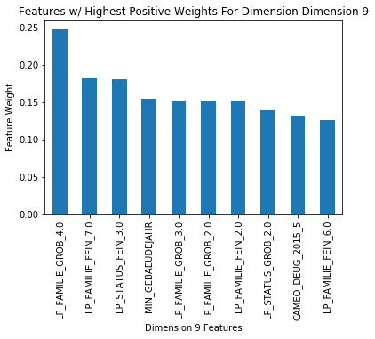

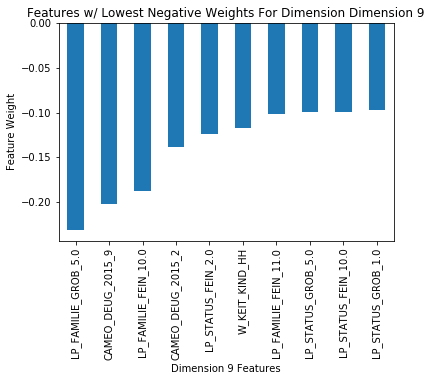

```python
# Analyze ninth component
nth_comp = 9
top_pos_comp, top_neg_comp = sort_pca_components(azdias_imputed_scaled, pca, nth_comp, 10)
plot_top_pca_weights(top_pos_comp, top_neg_comp)
```

The ninth principal component's top 10 positive and negative features by weight are:

| Top 10 Positive Features | Top 10 Negative Features |
| --- | --- |
| 1. LP_FAMILIE_GROB_4.0: Family type rough scale (family). Higher values indicate higher probability of living with a family. | 1. LP_FAMILIE_GROB_5.0: Family type rough scale (multi-person household). Lower values indicate lower probability of living in a multi-person household. |
| 2. LP_FAMILIE_FEIN_7.0: Family type fine scale (family with teenager). Higher values indicate higher probability of living with a family with teenage children. | 2. CAMEO_DEUG_2015_9: Wealth/life stage typology rough scale (urban working class). Lower values indicate lower probability of being part of the urban working class. |
| 3. LP_STATUS_FEIN_3.0: Social status fine scale (aspiring low-income earners). Higher values indicate higher probability of being an aspiring low-income earner. | 3. LP_FAMILIE_FEIN_10.0: Family type fine scale (two-generational household). Lower values indicate lower probability of being part of a two-generational household. |
| 4. MIN_GEBAEUDEJAHR: The first year the building mentioned in the database. Higher values indicate building was first mentioned in the database more recently | 4. CAMEO_DEUG_2015_2: Wealth/life stage typology rough scale (upper middleclass). Lower values indicate lower probability of being part of the upper middleclass. |
| 5. LP_FAMILIE_GROB_3.0: Family type rough scale (single-parent). Higher values indicate higher probability of being a single-parent. | 5. LP_STATUS_FEIN_2.0: Social status fine scale (orientation-seeking low income earners). Lower values indicate lower probability of being an orientation-seeking low income earner. |
| 6. LP_FAMILIE_GROB_2.0: Family type rough scale (couple). Higher values indicate higher probability of being a couple. | 6. W_KEIT_KIND_HH: Likelihood of children in household. Lower values indicate higher probability of having children. |
| 7. LP_FAMILIE_FEIN_2.0: Family type fine scale (couple). Higher values indicate higher probability of being a couple. | 7. LP_FAMILIE_FEIN_11.0: Family type fine scale (multi-generational household). Lower values indicate lower probability of being in a multi-generational household. |
| 8. LP_STATUS_GROB_2.0: Social status rough scale (average earners). Higher values indicate higher probability of being an average earner. | 8. LP_STATUS_GROB_5.0: Social status rough scale (top earners). Lower values indicate lower probability of being a top earner. |
| 9. CAMEO_DEUG_2015_5: Wealth/life stage typology rough scale (active middleclass). Higher values indicate higher probability of being part of the active middleclass. | 9. LP_STATUS_FEIN_10.0: Family type fine scale (top earners). Lower values indicate lower probability of being top earners. |
| 10. LP_FAMILIE_FEIN_6.0: Family type fine scale (young family). Higher values indicates higher probability of having a young family. | 10. LP_STATUS_GROB_1.0: Social status rough scale (low-income earners). Lower values indicate lower probability of being a low-income earner. |

The ninth principal component generally describes the middleclass family with young or teenage children. Single-parents and couples without children are also captured by the component, but they have a lower representation as compared to family with children. Individuals described here are also less likely to be part of the upper class and also less likely to live in multi-generational or multi-person household.

[output not shown]

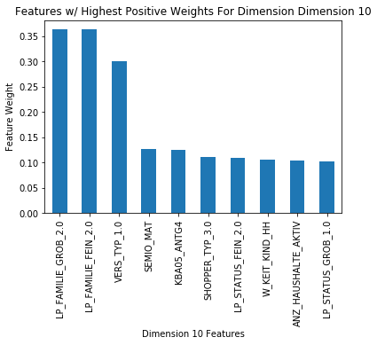

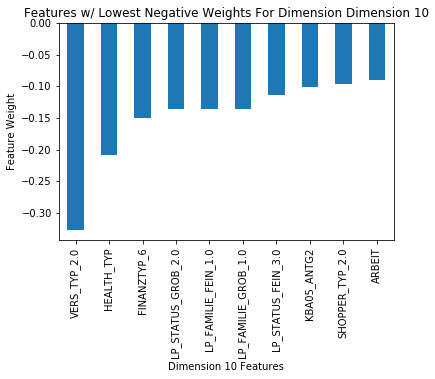

```python
# Analyze tenth component
nth_comp = 10
top_pos_comp, top_neg_comp = sort_pca_components(azdias_imputed_scaled, pca, nth_comp, 10)
plot_top_pca_weights(top_pos_comp, top_neg_comp)
```

The tenth principal component top 10 positive and negative features by weight are:

| Top 10 Positive Features | Top 10 Negative Features |
| --- | --- |
| 1. LP_FAMILIE_GROB_2.0: Family type rough scale (couple). Higher values indicate higher probability of being a couple. | 1. VERS_TYP_2.0: Insurance typology (individualistic-accepting risks). Lower values indicate lower probability of taking risks when purchasing insurance. |
| 2. LP_FAMILIE_FEIN_2.0: Family type fine scale (couple). Higher values indicate higher probability of being a couple. | 2. HEALTH_TYP: Health typology. Lower values indicate higher probability of being critical reserved and lower probability of being jaunty hedonists. |
| 3. VERS_TYP_1.0: Insurance typology (social-safety driven). Higher values indicate higher probability of seeking social security when buying insurance and accepting less risk. | 3. FINANZTYP_6: Most descriptive financial type (inconspicuous). Lower values indicate lower probability of being financially inconspicuous. |
| 4. SEMIO_MAT: Personality type (materialistic). Higher values indicate lower affinity of being materialistic. | 4. LP_STATUS_GROB_2.0: Social status rough scale (average earners). Lower values indicate lower probability of being an average earner. |
| 5. KBA05_ANTG4: Number of 10+ family house in the microcell. Higher values indicate higher share of family homes with more than 10 members in the microcell. | 5. LP_FAMILIE_FEIN_1.0: Family type fine scale (single). Lower values indicate lower probability of being single. |
| 6. SHOPPER_TYP_3.0: Shopper typology (demanding shopper). Higher values indicate higher probability of being a demanding shopper. | 6. LP_FAMILIE_GROB_1.0: Family type rough scale (single). Lower values indicate lower probability of being single. |
| 7. LP_STATUS_FEIN_2.0: Social status fine scale (orientation-seeking low-income earners). Higher values indicate higher probability of being an orientation seeking low-income earner. | 7. LP_STATUS_FEIN_3.0: Social status fine scale (aspiring low-income earners). Lower values indicate lower probability of being an aspiring low-income earners. |
| 8. W_KEIT_KIND_HH: Likelihood of children in household. Higher values indicate lower probability of having children in household. | 8. KBA05_ANTG2: Number of 3-5 family houses in microcell. Lower values indicate lower share of family homes with 3 to 5 members in the microcell. |
| 9. ANZ_HAUSHALTE_AKTIV: Number of households in the building. Higher values indicate higher number of households in the building. | 9. SHOPPER_TYP_2.0: Shopper typology (family-shopper). Lower values indicate lower probability of being a family shopper. |
| 10. LP_STATUS_GROB_1.0: Social status rough scale (low-income earners). Higher values indicate higher probability of being a low-income earner. | 10. ARBEIT: Share of unemployment in community. Lower values indicate lower share of unemployment in community. |

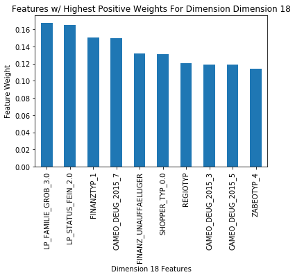

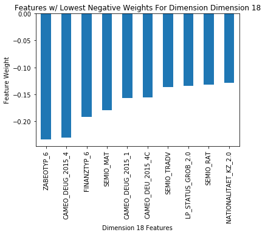

```python
# Analyze eighteen component
nth_comp = 18
top_pos_comp, top_neg_comp = sort_pca_components(azdias_imputed_scaled, pca, nth_comp, 10)
plot_top_pca_weights(top_pos_comp, top_neg_comp)
```

The eighteenth principal component's top 10 positive and negative features by weight are:

| Top 10 Positive Features | Top 10 Negative Features |
| --- | --- |
| 1. LP_FAMILIE_GROB_3.0: Family type rough scale (single-parent). Higher values indicate higher probability of being a single-parent. | 1. ZABEOTYP_6: Energy consumption typology (indifferent). Lower values indicate lower probability of being indifferent when purchasing energy. |
| 2. LP_STATUS_FEIN_2.0: Social status fine scale (orientation-seeking low-income earners). Higher values indicate higher probability of being an orientation seeking low-income earner. | 2. CAMEO_DEUG_2015_4: Wealth/life stage typology rough scale (consumption-oriented middleclass). Lower values indicate lower probability of being part of consumption-oriented middleclass. |
| 3. FINANZTYP_1: Most descriptive financial type for individual (low financial interest). Higher values indicate higher probability of having low financial interest. | 3. FINANZTYP_6: Most descriptive financial type for individual (inconspicuous). Lower values indicate lower probability of being financially inconspicuous. |
| 4. CAMEO_DEUG_2015_7: Wealth/life stage typology rough scale (lower middleclass). Higher values indicate higher probability of being part of the lower middleclass. | 4. SEMIO_MAT: Personal typology (materialistic). Lower values indicate higher affinity for being materialistic. |
| 5. FINANZ_UNAUFFAELLIGER: Most descriptive financial type for individual (inconspicuous). Higher values indicate lower probability of being financially inconspicuous. | 5. CAMEO_DEUG_2015_1: Wealth/life stage typology rough scale (upper class). Lower values indicate lower probability of being part of the upper class. |
| 6. SHOPPER_TYP_0.0: Shopper typology (external supplied hedonist). Higher values indicate higher probability of being an external supplied hedonist. | 6. CAMEO_DEU_2015_4C: Wealth/life stage typology fine scale (string trimmer). Lower values indicate lower probability of being a string trimmer. |
| 7. REGIOTYP: Neighbourhood typology. Higher values indicate less desirable neighbourhoods, with more members of lower class. | 7. SEMIO_TRADV: Personal typology (traditional-minded). Lower values indicate higher probability of being traditional-minded. |
| 8. CAMEO_DEUG_2015_3: Wealth/life stage typology rough scale (established middleclass). Higher values indicate higher probability of being part of the established middleclass. | 8. LP_STATUS_GROB_2.0: Social status rough scale (average-earners). Lower values indicate lower probability of being an average-earner. |
| 9. CAMEO_DEUG_2015_5: Wealth/life stage typology (active middleclass). Higher values indicate higher probability of being part of the active middleclass. | 9. SEMIO_RAT: Personality typology (rational). Lower values indicate higher probability of being rational |
| 10. ZABEOTYP_4: Energy consumption typology (price driven). Higher values indicate higher probability of price being the primary consideration when purchasing energy. | 10. NATIONALITAET_KZ_2.0: Nationality based on given name analysis (foreign-sounding). Lower values indicate lower probability of having foreign sounding names. |

The eighteenth principal component generally describes a low-income or middleclass single-parent. These individuals are less likely to be financially inconspicuous and foreign born, and are more likely to live in less desirable neighbourhoods and purchase energy from the cheapest provider. They are also more likely to be materialistic, rational and traditional-minded.

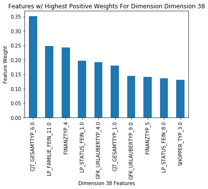

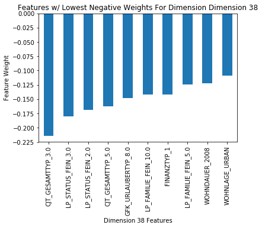

```python
# Analyze 38^th component
nth_comp = 38
top_pos_comp, top_neg_comp = sort_pca_components(azdias_imputed_scaled, pca, nth_comp, 10)
plot_top_pca_weights(top_pos_comp, top_neg_comp)
```

The thirty-eight principal component's top 10 positive and negative features by weight are:

| Top 10 Positive Features | Top 10 Negative Features |
| --- | --- |
| 1. CJT_GESAMTTYP_6.0: Customer-Journey-Typology preferred information and buying channels for consumer (Advertising-Enthusiast with restricted cross-channel behavior). Higher values indicate higher pr… | 1. CJT_GESAMTTYP_3.0: Customer-Journey-Typology preferred information and buying channels for consumer (Advertising interested store-shopper). Lower values indicate lower probability of being a shoppe… |
| 2. LP_FAMILIE_FEIN_11.0: Family type fine scale (multi-generational household). Higher values indicate higher probability of living in a multi-generational household. | 2. LP_STATUS_FEIN_3.0: Social status fine scale (aspiring low-income earners). Lower values indicate lower probability of being an aspiring low-income earner. |
| 3. FINANZTYP_4: Most descriptive financial type (be prepared). Higher values indicate higher probability of being financially prepared. | 3. LP_STATUS_FEIN_2.0: Social status fine scale (orientation-seeking low-income earners). Lower values indicate lower probability of being an orientation-seeking low-income earner. |
| 4. LP_STATUS_FEIN_1.0: Social status fine scale (typical low-income earners). Higher values indicate higher probability of being a typical low income earner. | 4. CJT_GESAMTTYP_5.0: Customer-Journey-Typology preferred information and buying channels for consumer (Advertising- and Cross-Channel Enthusiast). Lower values indicate lower probability of being a s… |
| 5. GFK_URLAUBERTYP_4.0: Vacation habits (culture lovers). Higher values indicate higher probability of enjoying cultural vacation destinations. | 5. GFK_URLAUBERTYP_8.0: Vacation habits (homeland-connected vacationists). Lower values indicate lower probability of travelling within the homeland. |
| 6. CJT_GESAMTTYP_1.0: Customer-Journey-Typology preferred information and buying channels for consumer (Advertising- and consumption-minimalist). Higher values indicate higher probability of being a s… | 6. LP_FAMILIE_FEIN_10.0: Family type fine scale (two-generational households). Lower values indicate lower probability of living in a two-generational households. |
| 7. GFK_URLAUBERTYP_9.0: Vacation habits (package tour travelers). Higher values indicate higher probability of joining package tours. | 7. FINANZTYP_1: Most descriptive financial type (low financial interest). Lower values indicate lower probability of having low financial interests. |
| 8. FINANZTYP_5: Most descriptive financial type (investor). Higher values indicate higher probability of being an investor. | 8. LP_FAMILIE_FEIN_5.0: Family type fine scale (single-parent with child of full age). Lower values indicate lower probability of being a single-parent with child of full age. |
| 9. LP_STATUS_FEIN_8.0: Social status fine scale (new house owners). Higher values indicate higher probability of being a new house owner. | 9. WOHNDAUER_2008: Length of residence. Lower values indicate fewer years of residency. |
| 10. SHOPPER_TYP_3.0: Shopper typology (demanding shopper). Higher values indicate higher probability of being a demanding shopper. | 10. WOHNLAGE_URBAN: Neighborhood quality for urban areas, where lower values are associated with higher quality. |

The thirty-eight principal component describes individuals who are demanding shoppers. They either consume a lot of traditional (not online) advertisments, or consume very little advertisments. They are either low-income earners who have little aspirations of moving up the income ladder, or are financially stable and own homes. Despite their income levels, they tend to be financially prepared and like to invest. In addition, they have an affinity for going on vacation and they enjoy cultural sights and/or participate in package tours. However, they are less likely to travel within their home country. They also have a higher likelihood of being recent immigrants as evident by shorter length of residency. Lastly, they have a higher probability of living in more desirable neighbourhoods.

### Discussion 3.3: Compare Customer Data to Demographics Data

Clusters 1, 3, 4 are overrepresented in the general population as compared to the customer dataset. Cluster 1 has significantly high means for principal components 2 and 1, at 3.3365 and 2.6449 respectively. Principal component 2 represents the elderly population as described previously and since its mean is relatively high for the first cluster, we can conclude that this population has a higher representation in the general population. The first principal component generally describes low income individuals living in less desirable neighbourboods in urban areas. They are less likely to own homes and are likely to live in households with larger family sizes. Furthermore, these individuals are less likely to be interested in financial products and services. Lastly, principal component 3 is also fairly represented in the first cluster with a mean of 0.5105. Principal component 3 describes the young male population that is previously mentioned. Because this component does not constitute a very significant proportion of both cluster 2 (mean of 0.8668) and cluster 1 (mean of 0.5105), it is likely that this group of individuals are well represented in both the customers dataset and the general population.

Cluster 4 does not seem to have a dominating group, and the cluster's top 3 principal components are 6, 9 and 38 with means of 0.4779, 0.3986 and 0.3408 respectively. Principal component 6 describes the middle class individuals who live in rural areas. These individuals are likely to be employed as farmers or in occupations that support the farming community. They enjoy relatively high purchasing power in the area they live in, and they predominantly reside in areas that are located in what was formerly known as East Germany. The ninth principal component predominantly describes the middleclass family with young or teenage children. Single-parents and couples without children are also represented by this component but to a lower extent. They are also less likely to be part of the upper class and also less likely to live in multi-generational or multi-person household. The thirty-eight principal component describes individuals who are demanding shoppers. They either consume a lot of traditional (not online) advertisments, or consume very little advertisments. They are either low-income earners who have little aspirations of moving up the income ladder, or are financially stable and own homes. Despite their income levels, they tend to be financially prepared and like to invest. In addition, they have an affinity for going on vacation and they enjoy cultural sights and/or participate in package tours. However, they are less likely to travel within their home country. They also have a higher likelihood of being recent immigrants as evident by shorter length of residency. Lastly, they have a higher probability to living in more desirable neighbourhoods.

Cluster 5 appears to be equally distributed between the general population and the customer dataset. In addition, the customer dataset contains a much higher proportion of rows containing missing values above the threshold of 30% as compared to the general population.

To summarize all of the above findings, this mail-order company is extremely popular with individuals who:

On the other hand, the mail-order company is less popular with these groups (A to G) of individuals:

Group A:

1. elderly
2. prefers shopping at brick and mortar stores as opposed to online shopping
3. more financially inconspicuous
4. more religious, rational, dutiful, traditional-minded and cultural-minded

Group B:

1. low-income home renters
2. less interested financially
3. live in households with larger family sizes

Group C:

Group D:

1. middle class individuals who live in rural areas
2. work as farmers or in occupations that support the farming community
3. high purchasing power in the area they live in
4. reside in areas that are located in what was formerly known as East Germany

Group G:

1. demanding shoppers
2. consume a lot of traditional (not online) advertisments or no advertisements at all
3. low-income earners who have little aspirations of moving up the income ladder, or are financially stable and own homes
4. financially prepared and like to invest
5. like going on vacation for cultural sightseeing and/or participating in package tours
6. less likely to travel within their home country
7. recent immigrants.
8. live in more desirable neighbourhoods

Finally, this mail-order company is indifferent to this group of individuals who:

1. are young unmarried males
2. have high-income
3. prefers the use of green energy
4. enjoys shopping for fun, entertainment and satisfaction
5. less family-minded, socially-minded and cultural-minded
6. less religious and dreamful
7. more rational, dominant-minded and critical-minded

> Congratulations on making it this far in the project! Before you finish, make sure to check through the entire notebook from top to bottom to make sure that your analysis follows a logical flow and all of your findings are documented in **Discussion** cells. Once you've checked over all of your work, you should export the notebook as an HTML document to submit for evaluation. You can do this from the menu, navigating to **File -> Download as -> HTML (.html)**. You will submit both that document and this notebook for your project submission.